# XGboost

610811101

2020/7/28

# 資料生成跑XGboost Feature Importances

ols_step_forward_p 部分看的P-value，好像就是原本model的P-value。

max_depth 預設值為6 。

用AIC或P-value來選，都基本是一樣的，但有的時候，用AIC會少選。

資料三和資料四，用AIC，都比較會少選。

## 資料一 (部分相關)

$x_{1 \sim 5}\sim MN(\mu_1 , \Sigma_1 )$  
$\mu_1=(0,0,0,0,0,0,0,0,0,0)$  
$\Sigma_1 = A^TDA$

$$D = \begin{pmatrix}
1 & 0 & 0 & 0 & 0 \\
0 & 1& 0 & 0 & 0 \\
0 & 0& 1 & 0 & 0 \\
0 & 0& 0 & 1 & 0 \\
0 & 0& 0 & 0 & 1
\end{pmatrix}$$

$$A = \begin{pmatrix}
0 & 2 & 2 & -2 & -1 \\
0 & 1& 0 & -2 & -2 \\
-1 & -2& 0 & 2 & 0 \\
-1 & -1& -2 & 0 & 1 \\
0 & 0& 1 & -1 & -2
\end{pmatrix}$$

$x_{6 \sim 10}\sim MN(\mu_2 , \Sigma_2 )$  
$\mu_2=(0,0,0,0,0,0,0,0,0,0)$

$$\Sigma_2 = \begin{pmatrix}
1 & 0 & 0 & 0 & 0 \\
0 & 1& 0 & 0 & 0 \\
0 & 0& 1 & 0 & 0 \\
0 & 0& 0 & 1 & 0 \\
0 & 0& 0 & 0 & 1
\end{pmatrix}$$

$x_{11} \sim N(0,1)$

$y=10x_1+5x_2-3x_3+4x_4+8x_5+10x_6+5x_7-3x_8+4x_9+8x_{10}+\epsilon$

$\epsilon \sim N(0,4)$

### 第一次

```r
#資料生成
set.seed(123)
a <- matrix(sample(-2:2,25,replace = T),5,5)
sigmas <- t(a)%*%diag(1,5)%*%a
set.seed(1253)
x <- rmvnorm(n = 100,mean = c(0,0,0,0,0),sigma = sigmas)
set.seed(173)
x2 <- rmvnorm(n = 100,mean = c(0,0,0,0,0),sigma = diag(1,5))
set.seed(59)
x_11 <- rnorm(n = 100)
set.seed(5)
sd <- rnorm(100,sd = 4)
y <- 10*x[,1]+5*x[,2]-3*x[,3]+4*x[,4]+8*x[,5]+10*x2[,1]+5*x2[,2]-3*x2[,3]+4*x2[,4]+8*x2[,5]+sd
sim <- data.frame(y,x,x2,x_11)


set.seed(192753)
x <- rmvnorm(n = 100,mean = c(0,0,0,0,0),sigma = sigmas)
set.seed(1783)
x2 <- rmvnorm(n = 100,mean = c(0,0,0,0,0),sigma = diag(1,5))
set.seed(599)
x_11 <- rnorm(n = 100)
set.seed(54)
sd <- rnorm(100,sd = 4)
y <- 10*x[,1]+5*x[,2]-3*x[,3]+4*x[,4]+8*x[,5]+10*x2[,1]+5*x2[,2]-3*x2[,3]+4*x2[,4]+8*x2[,5]+sd
sim_2 <- data.frame(y,x,x2,x_11)


set.seed(1962753)
x <- rmvnorm(n = 100,mean = c(0,0,0,0,0),sigma = sigmas)
set.seed(15783)
x2 <- rmvnorm(n = 100,mean = c(0,0,0,0,0),sigma = diag(1,5))
set.seed(4599)
x_11 <- rnorm(n = 100)
set.seed(534)
sd <- rnorm(100,sd = 4)
y <- 10*x[,1]+5*x[,2]-3*x[,3]+4*x[,4]+8*x[,5]+10*x2[,1]+5*x2[,2]-3*x2[,3]+4*x2[,4]+8*x2[,5]+sd
sim_3 <- data.frame(y,x,x2,x_11)

# sim_3 test data

names(sim) <- c("y",paste0("x",1:11))
names(sim_2) <- c("y",paste0("x",1:11))
names(sim_3) <- c("y",paste0("x",1:11))
```

#### use p-value to Variable Selection

```r
(old_data_lm <- lm(y~.,data = sim)) %>% summary()
```

```
##
## Call:
## lm(formula = y ~ ., data = sim)
##
## Residuals:
##     Min      1Q  Median      3Q     Max
## -9.1362 -2.2268 -0.4144  2.3636  8.6056
##
## Coefficients:
##             Estimate Std. Error t value Pr(>|t|)
## (Intercept)  0.03727    0.39360   0.095   0.9248
## x1           9.86754    0.54192  18.209  < 2e-16 ***
## x2           4.58374    0.88396   5.185 1.36e-06 ***
## x3          -2.56746    0.38335  -6.697 1.92e-09 ***
## x4           3.90892    0.73787   5.298 8.58e-07 ***
## x5           8.02288    0.44659  17.965  < 2e-16 ***
## x6           9.73258    0.37271  26.113  < 2e-16 ***
## x7           5.01367    0.41712  12.020  < 2e-16 ***
## x8          -3.09795    0.41899  -7.394 7.87e-11 ***
## x9           3.95036    0.37785  10.455  < 2e-16 ***
## x10          7.61245    0.39224  19.408  < 2e-16 ***
## x11          0.89042    0.40085   2.221   0.0289 *
## ---
## Signif. codes:  0 '***' 0.001 '**' 0.01 '*' 0.05 '.' 0.1 ' ' 1
##
## Residual standard error: 3.762 on 88 degrees of freedom
## Multiple R-squared:  0.9933, Adjusted R-squared:  0.9924
## F-statistic:  1178 on 11 and 88 DF,  p-value: < 2.2e-16
```

```r
old_data_lm %>% ols_step_forward_p()
```

```
##
##                              Selection Summary
## ----------------------------------------------------------------------------
##         Variable                  Adj.
## Step    Entered     R-Square    R-Square      C(p)         AIC        RMSE
## ----------------------------------------------------------------------------
##    1    x5            0.7033      0.7002    3774.7199    920.3771    23.6426
##    2    x1            0.8797      0.8772    1475.2366    832.0920    15.1311
##    3    x6            0.9244      0.9221     893.6843    787.5911    12.0544
##    4    x10           0.9617      0.9601     409.0857    721.5353     8.6226
##    5    x7            0.9769      0.9756     213.9178    673.2730     6.7421
##    6    x9            0.9834      0.9823     130.6655    642.0930     5.7420
##    7    x8            0.9892      0.9884      56.8344    601.0160     4.6545
##    8    x3            0.9906      0.9898      40.6392    589.1822     4.3672
##    9    x11           0.9911      0.9902      36.0718    585.6784     4.2722
## ----------------------------------------------------------------------------
```

```r
(old_data_lm %<>% ols_step_forward_aic())
```

```
##
##                            Selection Summary
## -----------------------------------------------------------------------
## Variable       AIC        Sum Sq         RSS        R-Sq      Adj. R-Sq
## -----------------------------------------------------------------------
## x5           920.377    129827.435    54779.103    0.70327      0.70024
## x1           832.092    162398.427    22208.111    0.87970      0.87722
## x6           787.591    170656.962    13949.576    0.92444      0.92207
## x10          721.535    177543.390     7063.148    0.96174      0.96013
## x7           673.273    180333.745     4272.793    0.97685      0.97562
## x9           642.093    181540.249     3066.289    0.98339      0.98232
## x8           601.016    182613.425     1993.112    0.98920      0.98838
## x3           589.182    182870.926     1735.612    0.99060      0.98977
## x11          585.678    182963.870     1642.668    0.99110      0.99021
## -----------------------------------------------------------------------
```

```r
md <- formula(y~x1+x3+x5+x6+x7+x8+x9+x10+x11)
VS <- c(1,3,5,6,7,8,9,10,11)+1
```

##### old data

###### regression

```r
old_data_lm$model %>% summary()
```

```
##
## Call:
## lm(formula = paste(response, "~", paste(preds, collapse = " + ")),
##     data = l)
##
## Residuals:
##     Min      1Q  Median      3Q     Max
## -11.235  -2.617  -0.384   2.978  11.164
##
## Coefficients:
##             Estimate Std. Error t value Pr(>|t|)
## (Intercept)  -0.2161     0.4429  -0.488 0.626797
## x5           10.2149     0.1795  56.920  < 2e-16 ***
## x1           12.1012     0.3227  37.502  < 2e-16 ***
## x6            9.9106     0.4207  23.557  < 2e-16 ***
## x10           7.8328     0.4392  17.833  < 2e-16 ***
## x7            5.2866     0.4700  11.248  < 2e-16 ***
## x9            4.1017     0.4275   9.594 2.00e-15 ***
## x8           -3.3015     0.4735  -6.973 5.03e-10 ***
## x3           -0.8733     0.2340  -3.731 0.000333 ***
## x11           1.0229     0.4533   2.257 0.026453 *
## ---
## Signif. codes:  0 '***' 0.001 '**' 0.01 '*' 0.05 '.' 0.1 ' ' 1
##
## Residual standard error: 4.272 on 90 degrees of freedom
## Multiple R-squared:  0.9911, Adjusted R-squared:  0.9902
## F-statistic:  1114 on 9 and 90 DF,  p-value: < 2.2e-16
```

```r
print("train MSE")
```

```
## [1] "train MSE"
```

```r
label  <- old_data_lm$model %>% predict(sim)
mean((sim$y-label)^2)
```

```
## [1] 16.42668
```

```r
print("test MSE")
```

```
## [1] "test MSE"
```

```r
label  <- old_data_lm$model %>% predict(sim_3)
mean((sim_3$y-label)^2)
```

```
## [1] 26.73555
```

###### XGboost

```r
old_data_xgb <- xgboost(data = data.matrix(sim[,VS]),
label = sim[,"y"],
# eta = 0.3,
# max_depth = 6,
nround= 25,
# subsample = 0.7,
# colsample_bytree = 0.7,
objective = "reg:squarederror",
verbose = 0
)
print("train MSE")
```

```
## [1] "train MSE"
```

```r
label  <- predict(old_data_xgb,xgb.DMatrix(data.matrix(sim[,VS])))
mean((sim$y-label)^2)
```

```
## [1] 0.2352246
```

```r
print("test MSE")
```

```
## [1] "test MSE"
```

```r
label  <- predict(old_data_xgb,xgb.DMatrix(data.matrix(sim_3[,VS])))
mean((sim_3$y-label)^2)
```

```
## [1] 236.498
```

```r
xgb.importance(model = old_data_xgb)
```

| Feature | Gain | Cover | Frequency |
| --- | --- | --- | --- |
| x5 | 0.781937552 | 0.42909169 | 0.23665893 |
| x1 | 0.102277107 | 0.23129106 | 0.27610209 |
| x6 | 0.039791599 | 0.11461011 | 0.12064965 |
| x10 | 0.039524440 | 0.05912596 | 0.06264501 |
| x9 | 0.012283682 | 0.02899172 | 0.05104408 |
| x7 | 0.011160297 | 0.06069694 | 0.08352668 |
| x8 | 0.008381976 | 0.03777492 | 0.06496520 |
| x3 | 0.003137369 | 0.01792345 | 0.06960557 |
| x11 | 0.001505978 | 0.02049414 | 0.03480278 |

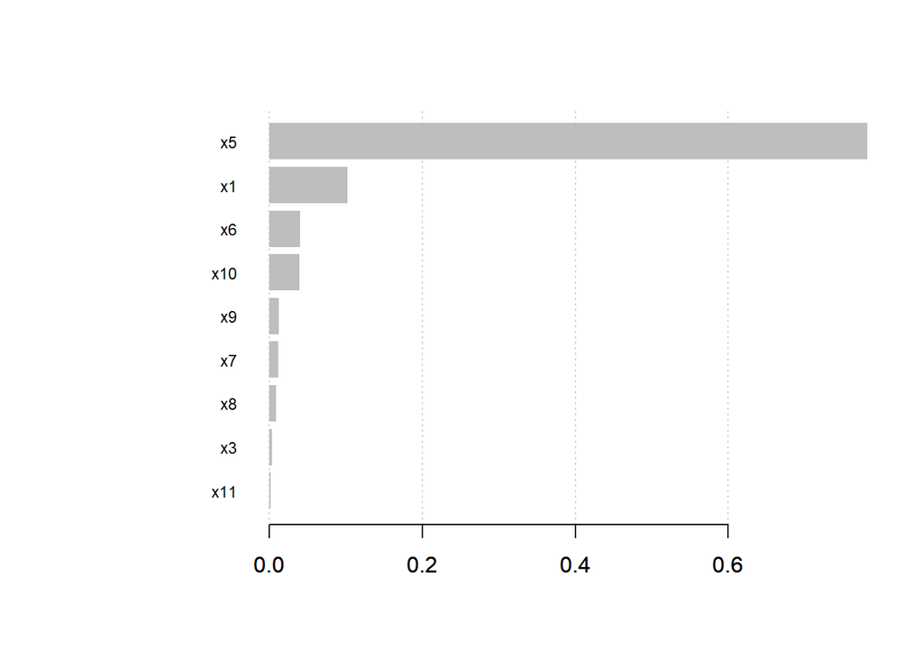

```r
xgb.importance(model = old_data_xgb) %>%
  xgb.plot.importance(top_n = 11)
```

##### new data

###### regression

```r
new_data_lm <- lm(md,data = sim_2)



new_data_lm %>% summary()
```

```
##
## Call:
## lm(formula = md, data = sim_2)
##
## Residuals:
##      Min       1Q   Median       3Q      Max
## -12.4443  -2.6729   0.1704   2.9378   9.5342
##
## Coefficients:
##             Estimate Std. Error t value Pr(>|t|)
## (Intercept)  -0.3143     0.4545  -0.691    0.491
## x1           12.6268     0.4120  30.649  < 2e-16 ***
## x3           -1.1295     0.2312  -4.886 4.45e-06 ***
## x5            9.8643     0.1889  52.221  < 2e-16 ***
## x6           10.2657     0.5047  20.340  < 2e-16 ***
## x7            4.4621     0.4733   9.428 4.43e-15 ***
## x8           -2.1612     0.4456  -4.851 5.13e-06 ***
## x9            4.2277     0.4791   8.825 7.97e-14 ***
## x10           8.1771     0.4707  17.372  < 2e-16 ***
## x11           0.4156     0.5091   0.816    0.416
## ---
## Signif. codes:  0 '***' 0.001 '**' 0.01 '*' 0.05 '.' 0.1 ' ' 1
##
## Residual standard error: 4.434 on 90 degrees of freedom
## Multiple R-squared:  0.9894, Adjusted R-squared:  0.9884
## F-statistic: 935.6 on 9 and 90 DF,  p-value: < 2.2e-16
```

```r
print("train MSE")
```

```
## [1] "train MSE"
```

```r
label  <- new_data_lm %>% predict(sim_2)
mean((sim_2$y-label)^2)
```

```
## [1] 17.69038
```

```r
print("test MSE")
```

```
## [1] "test MSE"
```

```r
label  <- new_data_lm %>% predict(sim_3)
mean((sim_3$y-label)^2)
```

```
## [1] 27.33
```

###### XGboost

```r
new_data_xgb <- xgboost(data = data.matrix(sim_2[,VS]),
label = sim_2[,"y"],
# eta = 0.5,
# max_depth = 10,
nround=25,
# subsample = 0.7,
# colsample_bytree = 0.7,
objective = "reg:squarederror",
verbose = 0
)
print("train MSE")
```

```
## [1] "train MSE"
```

```r
label  <- predict(new_data_xgb,xgb.DMatrix(data.matrix(sim_2[,VS])))
mean((sim_2$y-label)^2)
```

```
## [1] 0.04114912
```

```r
print("test MSE")
```

```
## [1] "test MSE"
```

```r
label  <- predict(new_data_xgb,xgb.DMatrix(data.matrix(sim_3[,VS])))
mean((sim_3$y-label)^2)
```

```
## [1] 355.727
```

```r
xgb.importance(model = new_data_xgb)
```

| Feature | Gain | Cover | Frequency |
| --- | --- | --- | --- |
| x5 | 0.834422238 | 0.32691886 | 0.18464052 |
| x1 | 0.078881674 | 0.14399649 | 0.25000000 |
| x7 | 0.036102277 | 0.05780347 | 0.07679739 |
| x6 | 0.016924092 | 0.14619156 | 0.12908497 |
| x10 | 0.015307214 | 0.12782615 | 0.08986928 |
| x8 | 0.008936265 | 0.04660862 | 0.06535948 |
| x3 | 0.003319150 | 0.03190166 | 0.08169935 |
| x9 | 0.003219276 | 0.04097461 | 0.05392157 |
| x11 | 0.002887813 | 0.07777859 | 0.06862745 |

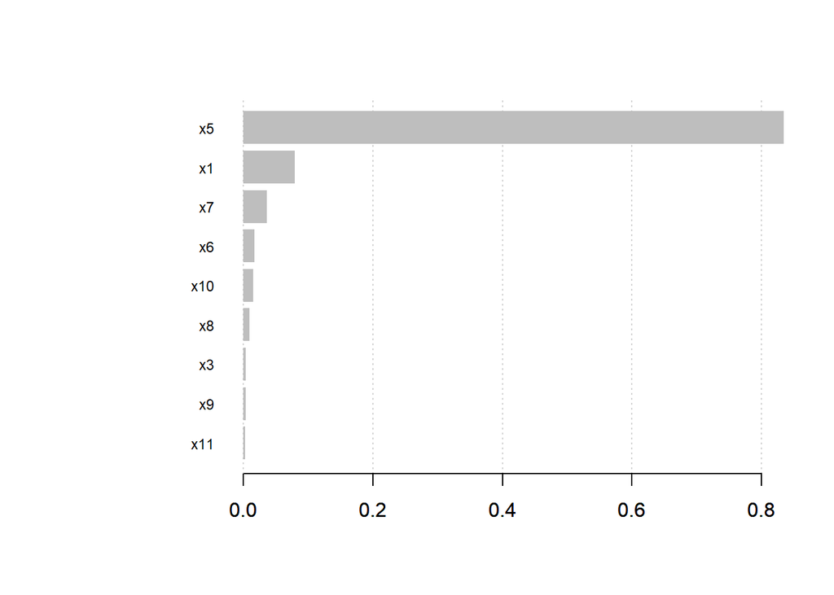

```r
xgb.importance(model = new_data_xgb) %>%
  xgb.plot.importance(top_n = 11)
```

#### use Gain to Variable Selection

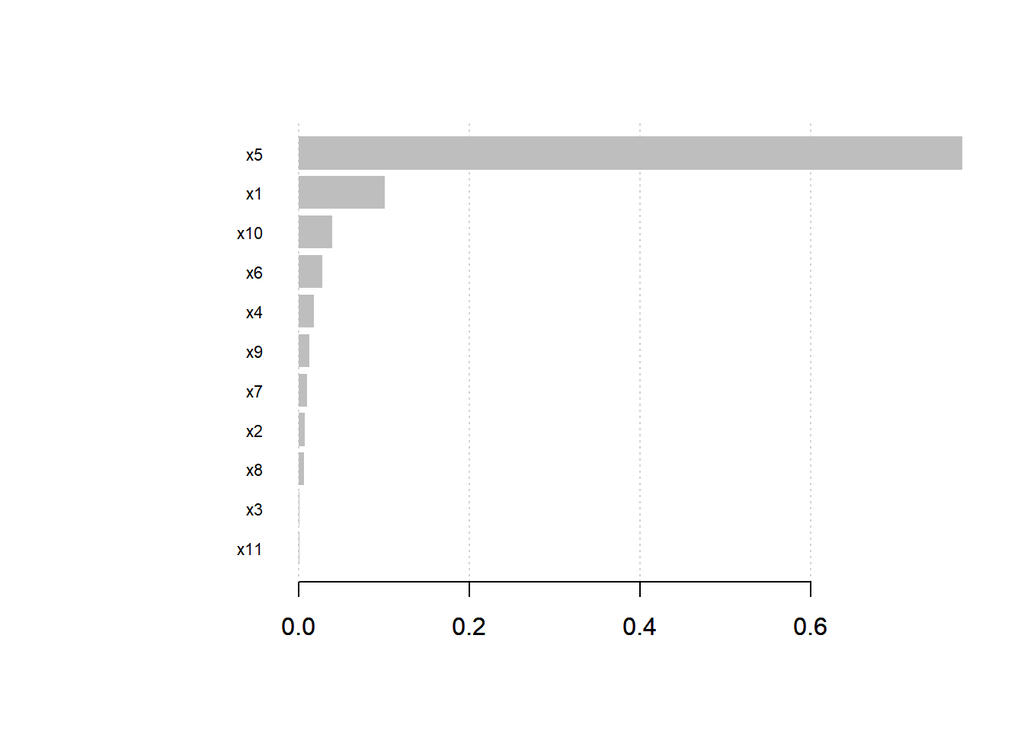

```r
xgb_test <- xgboost(data = data.matrix(sim[,-1]),
label = sim[,"y"],
# eta = 0.5,
# max_depth = 10,
nround=25,
# subsample = 0.7,
# colsample_bytree = 0.7,
objective = "reg:squarederror",
verbose = 0
)

xgb.importance(model = xgb_test) %>%
  xgb.plot.importance(top_n = 11)
```

```r
md <- formula(y~x1+x2+x3+x4+x5+x6+x7+x8+x10)
VS <- c(1,2,3,4,5,6,7,8,10)+1
```

##### old data

###### regression

```r
old_data_lm <- lm(md,data = sim)



old_data_lm %>% summary()
```

```
##
## Call:
## lm(formula = md, data = sim)
##
## Residuals:
##      Min       1Q   Median       3Q      Max
## -11.8235  -3.6786  -0.5563   3.7685  12.0769
##
## Coefficients:
##             Estimate Std. Error t value Pr(>|t|)
## (Intercept)  0.07138    0.57945   0.123 0.902234
## x1           9.72314    0.80557  12.070  < 2e-16 ***
## x2           5.28499    1.31004   4.034 0.000115 ***
## x3          -2.72703    0.56934  -4.790 6.54e-06 ***
## x4           4.55884    1.09372   4.168 7.04e-05 ***
## x5           7.71005    0.66341  11.622  < 2e-16 ***
## x6           9.29014    0.55105  16.859  < 2e-16 ***
## x7           5.09841    0.61988   8.225 1.40e-12 ***
## x8          -2.42917    0.61531  -3.948 0.000156 ***
## x10          7.15030    0.58037  12.320  < 2e-16 ***
## ---
## Signif. codes:  0 '***' 0.001 '**' 0.01 '*' 0.05 '.' 0.1 ' ' 1
##
## Residual standard error: 5.601 on 90 degrees of freedom
## Multiple R-squared:  0.9847, Adjusted R-squared:  0.9832
## F-statistic: 643.8 on 9 and 90 DF,  p-value: < 2.2e-16
```

```r
print("train MSE")
```

```
## [1] "train MSE"
```

```r
label  <- old_data_lm %>% predict(sim)
mean((sim$y-label)^2)
```

```
## [1] 28.23703
```

```r
print("test MSE")
```

```
## [1] "test MSE"
```

```r
label  <- old_data_lm %>% predict(sim_3)
mean((sim_3$y-label)^2)
```

```
## [1] 31.31251
```

###### XGboost

```r
old_data_xgb <- xgboost(data = data.matrix(sim[,VS]),
label = sim[,"y"],
# eta = 0.5,
# max_depth = 10,
nround=25,
# subsample = 0.7,
# colsample_bytree = 0.7,
objective = "reg:squarederror",
verbose = 0
)
print("train MSE")
```

```
## [1] "train MSE"
```

```r
label  <- predict(old_data_xgb,xgb.DMatrix(data.matrix(sim[,VS])))
mean((sim$y-label)^2)
```

```
## [1] 0.335673
```

```r
print("test MSE")
```

```
## [1] "test MSE"
```

```r
label  <- predict(old_data_xgb,xgb.DMatrix(data.matrix(sim_3[,VS])))
mean((sim_3$y-label)^2)
```

```
## [1] 209.6859
```

```r
xgb.importance(model = old_data_xgb)
```

| Feature | Gain | Cover | Frequency |
| --- | --- | --- | --- |
| x5 | 0.779768121 | 0.42604904 | 0.20608899 |
| x1 | 0.104309414 | 0.23682894 | 0.29508197 |
| x10 | 0.035771538 | 0.05818858 | 0.07728337 |
| x6 | 0.028149670 | 0.08749732 | 0.11007026 |
| x7 | 0.017310857 | 0.05690185 | 0.06791569 |
| x4 | 0.015696179 | 0.03559940 | 0.04449649 |
| x8 | 0.008218011 | 0.04181857 | 0.06557377 |
| x2 | 0.007611428 | 0.03324040 | 0.07025761 |
| x3 | 0.003164783 | 0.02387590 | 0.06323185 |

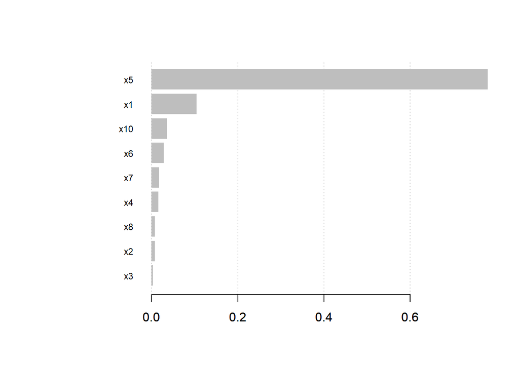

```r
xgb.importance(model = old_data_xgb) %>%
  xgb.plot.importance(top_n = 11)
```

##### new data

###### regression

```r
new_data_lm <- lm(md,data = sim_2)



new_data_lm %>% summary()
```

```
##
## Call:
## lm(formula = md, data = sim_2)
##
## Residuals:
##      Min       1Q   Median       3Q      Max
## -14.3886  -3.8468  -0.4556   3.6018  13.5809
##
## Coefficients:
##             Estimate Std. Error t value Pr(>|t|)
## (Intercept)  -0.4571     0.6039  -0.757   0.4511
## x1           11.2581     0.8985  12.530  < 2e-16 ***
## x2            3.4097     1.4346   2.377   0.0196 *
## x3           -2.8230     0.6576  -4.293 4.43e-05 ***
## x4            2.7393     1.2471   2.197   0.0306 *
## x5            8.4150     0.7435  11.318  < 2e-16 ***
## x6           10.0649     0.6661  15.110  < 2e-16 ***
## x7            4.3437     0.6216   6.988 4.70e-10 ***
## x8           -2.4382     0.5932  -4.110 8.72e-05 ***
## x10           7.4625     0.5967  12.506  < 2e-16 ***
## ---
## Signif. codes:  0 '***' 0.001 '**' 0.01 '*' 0.05 '.' 0.1 ' ' 1
##
## Residual standard error: 5.904 on 90 degrees of freedom
## Multiple R-squared:  0.9812, Adjusted R-squared:  0.9794
## F-statistic: 523.3 on 9 and 90 DF,  p-value: < 2.2e-16
```

```r
print("train MSE")
```

```
## [1] "train MSE"
```

```r
label  <- new_data_lm %>% predict(sim_2)
mean((sim_2$y-label)^2)
```

```
## [1] 31.3668
```

```r
print("test MSE")
```

```
## [1] "test MSE"
```

```r
label  <- new_data_lm %>% predict(sim_3)
mean((sim_3$y-label)^2)
```

```
## [1] 28.75823
```

###### XGboost

```r
new_data_xgb <- xgboost(data = data.matrix(sim_2[,VS]),
label = sim_2[,"y"],
# eta = 0.5,
# max_depth = 10,
nround=25,
# subsample = 0.7,
# colsample_bytree = 0.7,
objective = "reg:squarederror",
verbose = 0
)
print("train MSE")
```

```
## [1] "train MSE"
```

```r
label  <- predict(new_data_xgb,xgb.DMatrix(data.matrix(sim_2[,VS])))
mean((sim_2$y-label)^2)
```

```
## [1] 0.03724172
```

```r
print("test MSE")
```

```
## [1] "test MSE"
```

```r
label  <- predict(new_data_xgb,xgb.DMatrix(data.matrix(sim_3[,VS])))
mean((sim_3$y-label)^2)
```

```
## [1] 331.3129
```

```r
xgb.importance(model = new_data_xgb)
```

| Feature | Gain | Cover | Frequency |
| --- | --- | --- | --- |
| x5 | 0.830860575 | 0.28735632 | 0.13509317 |
| x1 | 0.079656735 | 0.15531978 | 0.27173913 |
| x7 | 0.032716934 | 0.07139699 | 0.09006211 |
| x6 | 0.016756008 | 0.15045682 | 0.14596273 |
| x10 | 0.013621677 | 0.12076334 | 0.08074534 |
| x8 | 0.008988799 | 0.04796640 | 0.05434783 |
| x4 | 0.007693769 | 0.05806071 | 0.06055901 |
| x3 | 0.005024544 | 0.06167109 | 0.07919255 |
| x2 | 0.004680958 | 0.04700855 | 0.08229814 |

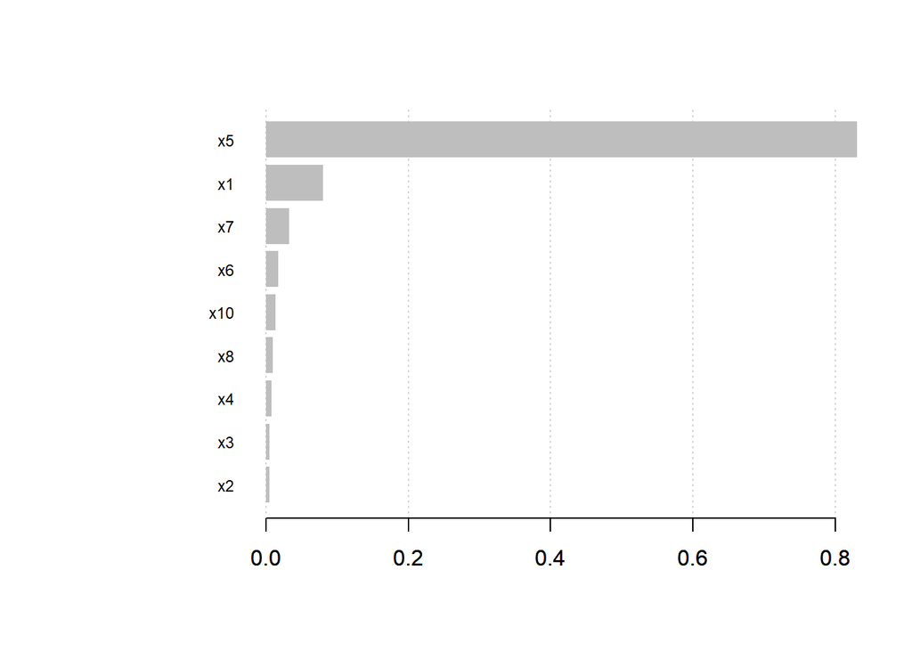

```r
xgb.importance(model = new_data_xgb) %>%
  xgb.plot.importance(top_n = 11)
```

### 第二次

```r
#資料生成
set.seed(123)
a <- matrix(sample(-2:2,25,replace = T),5,5)
sigmas <- t(a)%*%diag(1,5)%*%a
set.seed(155253)
x <- rmvnorm(n = 100,mean = c(0,0,0,0,0),sigma = sigmas)
set.seed(6173)
x2 <- rmvnorm(n = 100,mean = c(0,0,0,0,0),sigma = diag(1,5))
set.seed(579)
x_11 <- rnorm(n = 100)
set.seed(85)
sd <- rnorm(100,sd = 4)
y <- 10*x[,1]+5*x[,2]-3*x[,3]+4*x[,4]+8*x[,5]+10*x2[,1]+5*x2[,2]-3*x2[,3]+4*x2[,4]+8*x2[,5]+sd
sim <- data.frame(y,x,x2,x_11)


set.seed(19923)
x <- rmvnorm(n = 100,mean = c(0,0,0,0,0),sigma = sigmas)
set.seed(175483)
x2 <- rmvnorm(n = 100,mean = c(0,0,0,0,0),sigma = diag(1,5))
set.seed(5969)
x_11 <- rnorm(n = 100)
set.seed(547)
sd <- rnorm(100,sd = 4)
y <- 10*x[,1]+5*x[,2]-3*x[,3]+4*x[,4]+8*x[,5]+10*x2[,1]+5*x2[,2]-3*x2[,3]+4*x2[,4]+8*x2[,5]+sd
sim_2 <- data.frame(y,x,x2,x_11)


set.seed(1962752)
x <- rmvnorm(n = 100,mean = c(0,0,0,0,0),sigma = sigmas)
set.seed(15743)
x2 <- rmvnorm(n = 100,mean = c(0,0,0,0,0),sigma = diag(1,5))
set.seed(499)
x_11 <- rnorm(n = 100)
set.seed(5234)
sd <- rnorm(100,sd = 4)
y <- 10*x[,1]+5*x[,2]-3*x[,3]+4*x[,4]+8*x[,5]+10*x2[,1]+5*x2[,2]-3*x2[,3]+4*x2[,4]+8*x2[,5]+sd
sim_3 <- data.frame(y,x,x2,x_11)



names(sim) <- c("y",paste0("x",1:11))
names(sim_2) <- c("y",paste0("x",1:11))
names(sim_3) <- c("y",paste0("x",1:11))
```

#### use p-value to Variable Selection

```r
(old_data_lm <- lm(y~.,data = sim)) %>% summary()
```

```
##
## Call:
## lm(formula = y ~ ., data = sim)
##
## Residuals:
##     Min      1Q  Median      3Q     Max
## -8.4214 -2.5767 -0.2822  2.1791  8.9720
##
## Coefficients:
##             Estimate Std. Error t value Pr(>|t|)
## (Intercept)  -1.5321     0.4024  -3.807 0.000259 ***
## x1           10.2526     0.6102  16.802  < 2e-16 ***
## x2            5.1065     0.9029   5.656 1.90e-07 ***
## x3           -3.3532     0.3969  -8.448 5.61e-13 ***
## x4            3.8893     0.7663   5.075 2.14e-06 ***
## x5            7.9547     0.4712  16.880  < 2e-16 ***
## x6           10.2051     0.3874  26.341  < 2e-16 ***
## x7            4.7352     0.4283  11.055  < 2e-16 ***
## x8           -3.2810     0.4037  -8.127 2.56e-12 ***
## x9            3.8166     0.4061   9.398 6.22e-15 ***
## x10           8.2819     0.4576  18.099  < 2e-16 ***
## x11          -0.5852     0.3808  -1.537 0.127961
## ---
## Signif. codes:  0 '***' 0.001 '**' 0.01 '*' 0.05 '.' 0.1 ' ' 1
##
## Residual standard error: 3.931 on 88 degrees of freedom
## Multiple R-squared:  0.9897, Adjusted R-squared:  0.9884
## F-statistic: 769.4 on 11 and 88 DF,  p-value: < 2.2e-16
```

```r
old_data_lm %>% ols_step_forward_p()
```

```
##
##                              Selection Summary
## ----------------------------------------------------------------------------
##         Variable                  Adj.
## Step    Entered     R-Square    R-Square      C(p)         AIC        RMSE
## ----------------------------------------------------------------------------
##    1    x5            0.6370      0.6333    3007.7495    907.0905    22.1229
##    2    x1            0.7972      0.7930    1640.4912    850.9008    16.6231
##    3    x6            0.8952      0.8919     803.9403    786.8412    12.0093
##    4    x10           0.9417      0.9392     408.9263    730.2997     9.0088
##    5    x7            0.9545      0.9521     300.7665    707.3517     7.9945
##    6    x9            0.9684      0.9664     183.9034    672.8603     6.6969
##    7    x8            0.9787      0.9771      97.9599    635.4325     5.5285
##    8    x3            0.9852      0.9839      44.3610    600.9681     4.6323
##    9    x2            0.9862      0.9848      38.2215    596.3098     4.5055
##   10    x4            0.9894      0.9882      12.3614    571.4355     3.9610
##   11    x11           0.9897      0.9884      12.0000    570.7875     3.9311
## ----------------------------------------------------------------------------
```

```r
(old_data_lm %<>% ols_step_forward_aic())
```

```
##
##                            Selection Summary
## -----------------------------------------------------------------------
## Variable       AIC        Sum Sq         RSS        R-Sq      Adj. R-Sq
## -----------------------------------------------------------------------
## x5           907.090     84176.660    47963.600    0.63703      0.63332
## x1           850.901    105336.409    26803.851    0.79716      0.79297
## x6           786.841    118294.903    13845.358    0.89522      0.89195
## x10          730.300    124430.133     7710.127    0.94165      0.93920
## x7           707.352    126132.481     6007.779    0.95453      0.95212
## x9           672.860    127969.324     4170.936    0.96844      0.96640
## x8           635.432    129328.354     2811.906    0.97872      0.97710
## x3           600.968    130187.549     1952.712    0.98522      0.98392
## x2           596.310    130313.332     1826.928    0.98617      0.98479
## x4           571.436    130743.866     1396.394    0.98943      0.98825
## x11          570.788    130780.358     1359.903    0.98971      0.98842
## -----------------------------------------------------------------------
```

```r
md <- formula(y~.)
VS <- 1:11+1
```

##### old data

###### regression

```r
old_data_lm$model %>% summary()
```

```
##
## Call:
## lm(formula = paste(response, "~", paste(preds, collapse = " + ")),
##     data = l)
##
## Residuals:
##     Min      1Q  Median      3Q     Max
## -8.4214 -2.5767 -0.2822  2.1791  8.9720
##
## Coefficients:
##             Estimate Std. Error t value Pr(>|t|)
## (Intercept)  -1.5321     0.4024  -3.807 0.000259 ***
## x5            7.9547     0.4712  16.880  < 2e-16 ***
## x1           10.2526     0.6102  16.802  < 2e-16 ***
## x6           10.2051     0.3874  26.341  < 2e-16 ***
## x10           8.2819     0.4576  18.099  < 2e-16 ***
## x7            4.7352     0.4283  11.055  < 2e-16 ***
## x9            3.8166     0.4061   9.398 6.22e-15 ***
## x8           -3.2810     0.4037  -8.127 2.56e-12 ***
## x3           -3.3532     0.3969  -8.448 5.61e-13 ***
## x2            5.1065     0.9029   5.656 1.90e-07 ***
## x4            3.8893     0.7663   5.075 2.14e-06 ***
## x11          -0.5852     0.3808  -1.537 0.127961
## ---
## Signif. codes:  0 '***' 0.001 '**' 0.01 '*' 0.05 '.' 0.1 ' ' 1
##
## Residual standard error: 3.931 on 88 degrees of freedom
## Multiple R-squared:  0.9897, Adjusted R-squared:  0.9884
## F-statistic: 769.4 on 11 and 88 DF,  p-value: < 2.2e-16
```

```r
print("train MSE")
```

```
## [1] "train MSE"
```

```r
label  <- old_data_lm$model %>% predict(sim)
mean((sim$y-label)^2)
```

```
## [1] 13.59903
```

```r
print("test MSE")
```

```
## [1] "test MSE"
```

```r
label  <- old_data_lm$model %>% predict(sim_3)
mean((sim_3$y-label)^2)
```

```
## [1] 19.74559
```

###### XGboost

```r
old_data_xgb <- xgboost(data = data.matrix(sim[,VS]),
label = sim[,"y"],
# eta = 0.3,
# max_depth = 6,
nround= 25,
# subsample = 0.7,
# colsample_bytree = 0.7,
objective = "reg:squarederror",
verbose = 0
)
print("train MSE")
```

```
## [1] "train MSE"
```

```r
label  <- predict(old_data_xgb,xgb.DMatrix(data.matrix(sim[,VS])))
mean((sim$y-label)^2)
```

```
## [1] 0.1026711
```

```r
print("test MSE")
```

```
## [1] "test MSE"
```

```r
label  <- predict(old_data_xgb,xgb.DMatrix(data.matrix(sim_3[,VS])))
mean((sim_3$y-label)^2)
```

```
## [1] 317.1775
```

```r
xgb.importance(model = old_data_xgb)
```

| Feature | Gain | Cover | Frequency |
| --- | --- | --- | --- |
| x5 | 0.7071558414 | 0.38584557 | 0.17550274 |
| x6 | 0.1228364883 | 0.13155800 | 0.09140768 |
| x1 | 0.0826552334 | 0.19060714 | 0.28336380 |
| x10 | 0.0239706920 | 0.05297055 | 0.05667276 |
| x8 | 0.0177224471 | 0.05738476 | 0.06764168 |
| x7 | 0.0167104141 | 0.05680585 | 0.05667276 |
| x3 | 0.0118290857 | 0.04501049 | 0.08043876 |
| x4 | 0.0068339186 | 0.00875606 | 0.02010969 |
| x2 | 0.0054292318 | 0.02699182 | 0.09872029 |
| x9 | 0.0041961626 | 0.03531370 | 0.04753199 |

[output cut: 1 more lines]

```r
xgb.importance(model = old_data_xgb) %>%
  xgb.plot.importance(top_n = 11)
```

[output not shown]

##### new data

###### regression

```r
new_data_lm <- lm(md,data = sim_2)



new_data_lm %>% summary()
```

```
##
## Call:
## lm(formula = md, data = sim_2)
##
## Residuals:
##     Min      1Q  Median      3Q     Max
## -12.335  -2.154   0.178   2.617   9.592
##
## Coefficients:
##             Estimate Std. Error t value Pr(>|t|)
## (Intercept)  -0.2615     0.4625  -0.565    0.573
## x1           10.2965     0.6560  15.695  < 2e-16 ***
## x2            5.0567     0.9255   5.464 4.28e-07 ***
## x3           -3.2868     0.4643  -7.079 3.37e-10 ***
## x4            4.3908     0.8195   5.358 6.68e-07 ***
## x5            7.7608     0.5471  14.185  < 2e-16 ***
## x6           10.6906     0.5255  20.343  < 2e-16 ***
## x7            4.4273     0.4716   9.388 6.52e-15 ***
## x8           -1.9728     0.4725  -4.175 6.98e-05 ***
## x9            4.1167     0.4864   8.464 5.20e-13 ***
## x10           7.8576     0.4542  17.298  < 2e-16 ***
## x11          -0.2568     0.5123  -0.501    0.617
## ---
## Signif. codes:  0 '***' 0.001 '**' 0.01 '*' 0.05 '.' 0.1 ' ' 1
##
## Residual standard error: 4.421 on 88 degrees of freedom
## Multiple R-squared:  0.9874, Adjusted R-squared:  0.9858
## F-statistic: 627.4 on 11 and 88 DF,  p-value: < 2.2e-16
```

```r
print("train MSE")
```

```
## [1] "train MSE"
```

```r
label  <- new_data_lm %>% predict(sim_2)
mean((sim_2$y-label)^2)
```

```
## [1] 17.19813
```

```r
print("test MSE")
```

```
## [1] "test MSE"
```

```r
label  <- new_data_lm %>% predict(sim_3)
mean((sim_3$y-label)^2)
```

```
## [1] 18.56505
```

###### XGboost

```r
new_data_xgb <- xgboost(data = data.matrix(sim_2[,VS]),
label = sim_2[,"y"],
# eta = 0.5,
# max_depth = 10,
nround=25,
# subsample = 0.7,
# colsample_bytree = 0.7,
objective = "reg:squarederror",
verbose = 0
)
print("train MSE")
```

```
## [1] "train MSE"
```

```r
label  <- predict(new_data_xgb,xgb.DMatrix(data.matrix(sim_2[,VS])))
mean((sim_2$y-label)^2)
```

```
## [1] 0.1360923
```

```r
print("test MSE")
```

```
## [1] "test MSE"
```

```r
label  <- predict(new_data_xgb,xgb.DMatrix(data.matrix(sim_3[,VS])))
mean((sim_3$y-label)^2)
```

```
## [1] 342.8027
```

```r
xgb.importance(model = new_data_xgb)
```

| Feature | Gain | Cover | Frequency |
| --- | --- | --- | --- |
| x5 | 0.763708817 | 0.41547671 | 0.20283976 |
| x6 | 0.084596531 | 0.13096783 | 0.10547667 |
| x1 | 0.058578705 | 0.16399827 | 0.24746450 |
| x10 | 0.029359902 | 0.07247945 | 0.07302231 |
| x7 | 0.018935917 | 0.05344007 | 0.06693712 |
| x8 | 0.016382020 | 0.02791000 | 0.04868154 |
| x9 | 0.013299896 | 0.03223713 | 0.05273834 |
| x3 | 0.007094399 | 0.03317467 | 0.06085193 |
| x4 | 0.003733648 | 0.02170777 | 0.03853955 |
| x2 | 0.002884167 | 0.03057839 | 0.07302231 |

[output cut: 1 more lines]

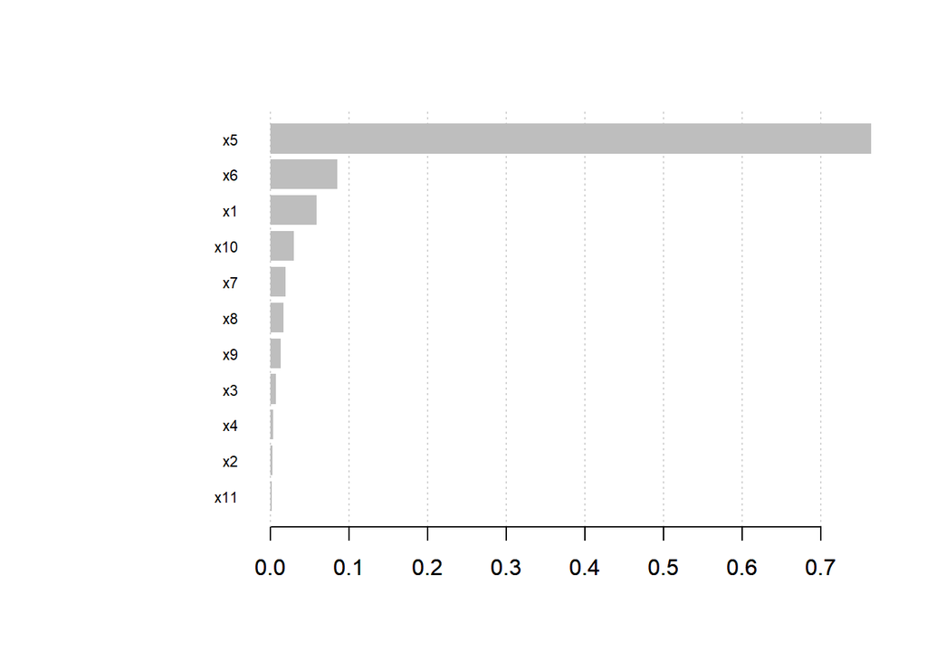

```r
xgb.importance(model = new_data_xgb) %>%
  xgb.plot.importance(top_n = 11)
```

#### use Gain to Variable Selection

```r
xgb_test <- xgboost(data = data.matrix(sim[,-1]),
label = sim[,"y"],
# eta = 0.5,
# max_depth = 10,
nround=25,
# subsample = 0.7,
# colsample_bytree = 0.7,
objective = "reg:squarederror",
verbose = 0
)

xgb.importance(model = xgb_test) %>%
  xgb.plot.importance(top_n = 11)
```

[output not shown]

```r
md <- formula(y~.)
VS <- 1:11+1
```

##### old data

###### regression

```r
old_data_lm <- lm(md,data = sim)



old_data_lm %>% summary()
```

```
##
## Call:
## lm(formula = md, data = sim)
##
## Residuals:
##     Min      1Q  Median      3Q     Max
## -8.4214 -2.5767 -0.2822  2.1791  8.9720
##
## Coefficients:
##             Estimate Std. Error t value Pr(>|t|)
## (Intercept)  -1.5321     0.4024  -3.807 0.000259 ***
## x1           10.2526     0.6102  16.802  < 2e-16 ***
## x2            5.1065     0.9029   5.656 1.90e-07 ***
## x3           -3.3532     0.3969  -8.448 5.61e-13 ***
## x4            3.8893     0.7663   5.075 2.14e-06 ***
## x5            7.9547     0.4712  16.880  < 2e-16 ***
## x6           10.2051     0.3874  26.341  < 2e-16 ***
## x7            4.7352     0.4283  11.055  < 2e-16 ***
## x8           -3.2810     0.4037  -8.127 2.56e-12 ***
## x9            3.8166     0.4061   9.398 6.22e-15 ***
## x10           8.2819     0.4576  18.099  < 2e-16 ***
## x11          -0.5852     0.3808  -1.537 0.127961
## ---
## Signif. codes:  0 '***' 0.001 '**' 0.01 '*' 0.05 '.' 0.1 ' ' 1
##
## Residual standard error: 3.931 on 88 degrees of freedom
## Multiple R-squared:  0.9897, Adjusted R-squared:  0.9884
## F-statistic: 769.4 on 11 and 88 DF,  p-value: < 2.2e-16
```

```r
print("train MSE")
```

```
## [1] "train MSE"
```

```r
label  <- old_data_lm %>% predict(sim)
mean((sim$y-label)^2)
```

```
## [1] 13.59903
```

```r
print("test MSE")
```

```
## [1] "test MSE"
```

```r
label  <- old_data_lm %>% predict(sim_3)
mean((sim_3$y-label)^2)
```

```
## [1] 19.74559
```

###### XGboost

```r
old_data_xgb <- xgboost(data = data.matrix(sim[,VS]),
label = sim[,"y"],
# eta = 0.5,
# max_depth = 10,
nround=25,
# subsample = 0.7,
# colsample_bytree = 0.7,
objective = "reg:squarederror",
verbose = 0
)
print("train MSE")
```

```
## [1] "train MSE"
```

```r
label  <- predict(old_data_xgb,xgb.DMatrix(data.matrix(sim[,VS])))
mean((sim$y-label)^2)
```

```
## [1] 0.1026711
```

```r
print("test MSE")
```

```
## [1] "test MSE"
```

```r
label  <- predict(old_data_xgb,xgb.DMatrix(data.matrix(sim_3[,VS])))
mean((sim_3$y-label)^2)
```

```
## [1] 317.1775
```

```r
xgb.importance(model = old_data_xgb)
```

| Feature | Gain | Cover | Frequency |
| --- | --- | --- | --- |
| x5 | 0.7071558414 | 0.38584557 | 0.17550274 |
| x6 | 0.1228364883 | 0.13155800 | 0.09140768 |
| x1 | 0.0826552334 | 0.19060714 | 0.28336380 |
| x10 | 0.0239706920 | 0.05297055 | 0.05667276 |
| x8 | 0.0177224471 | 0.05738476 | 0.06764168 |
| x7 | 0.0167104141 | 0.05680585 | 0.05667276 |
| x3 | 0.0118290857 | 0.04501049 | 0.08043876 |
| x4 | 0.0068339186 | 0.00875606 | 0.02010969 |
| x2 | 0.0054292318 | 0.02699182 | 0.09872029 |
| x9 | 0.0041961626 | 0.03531370 | 0.04753199 |

[output cut: 1 more lines]

```r
xgb.importance(model = old_data_xgb) %>%
  xgb.plot.importance(top_n = 11)
```

[output not shown]

##### new data

###### regression

```r
new_data_lm <- lm(md,data = sim_2)



new_data_lm %>% summary()
```

```
##
## Call:
## lm(formula = md, data = sim_2)
##
## Residuals:
##     Min      1Q  Median      3Q     Max
## -12.335  -2.154   0.178   2.617   9.592
##
## Coefficients:
##             Estimate Std. Error t value Pr(>|t|)
## (Intercept)  -0.2615     0.4625  -0.565    0.573
## x1           10.2965     0.6560  15.695  < 2e-16 ***
## x2            5.0567     0.9255   5.464 4.28e-07 ***
## x3           -3.2868     0.4643  -7.079 3.37e-10 ***
## x4            4.3908     0.8195   5.358 6.68e-07 ***
## x5            7.7608     0.5471  14.185  < 2e-16 ***
## x6           10.6906     0.5255  20.343  < 2e-16 ***
## x7            4.4273     0.4716   9.388 6.52e-15 ***
## x8           -1.9728     0.4725  -4.175 6.98e-05 ***
## x9            4.1167     0.4864   8.464 5.20e-13 ***
## x10           7.8576     0.4542  17.298  < 2e-16 ***
## x11          -0.2568     0.5123  -0.501    0.617
## ---
## Signif. codes:  0 '***' 0.001 '**' 0.01 '*' 0.05 '.' 0.1 ' ' 1
##
## Residual standard error: 4.421 on 88 degrees of freedom
## Multiple R-squared:  0.9874, Adjusted R-squared:  0.9858
## F-statistic: 627.4 on 11 and 88 DF,  p-value: < 2.2e-16
```

```r
print("train MSE")
```

```
## [1] "train MSE"
```

```r
label  <- new_data_lm %>% predict(sim_2)
mean((sim_2$y-label)^2)
```

```
## [1] 17.19813
```

```r
print("test MSE")
```

```
## [1] "test MSE"
```

```r
label  <- new_data_lm %>% predict(sim_3)
mean((sim_3$y-label)^2)
```

```
## [1] 18.56505
```

###### XGboost

```r
new_data_xgb <- xgboost(data = data.matrix(sim_2[,VS]),
label = sim_2[,"y"],
# eta = 0.5,
# max_depth = 10,
nround=25,
# subsample = 0.7,
# colsample_bytree = 0.7,
objective = "reg:squarederror",
verbose = 0
)
print("train MSE")
```

```
## [1] "train MSE"
```

```r
label  <- predict(new_data_xgb,xgb.DMatrix(data.matrix(sim_2[,VS])))
mean((sim_2$y-label)^2)
```

```
## [1] 0.1360923
```

```r
print("test MSE")
```

```
## [1] "test MSE"
```

```r
label  <- predict(new_data_xgb,xgb.DMatrix(data.matrix(sim_3[,VS])))
mean((sim_3$y-label)^2)
```

```
## [1] 342.8027
```

```r
xgb.importance(model = new_data_xgb)
```

| Feature | Gain | Cover | Frequency |
| --- | --- | --- | --- |
| x5 | 0.763708817 | 0.41547671 | 0.20283976 |
| x6 | 0.084596531 | 0.13096783 | 0.10547667 |
| x1 | 0.058578705 | 0.16399827 | 0.24746450 |
| x10 | 0.029359902 | 0.07247945 | 0.07302231 |
| x7 | 0.018935917 | 0.05344007 | 0.06693712 |
| x8 | 0.016382020 | 0.02791000 | 0.04868154 |
| x9 | 0.013299896 | 0.03223713 | 0.05273834 |
| x3 | 0.007094399 | 0.03317467 | 0.06085193 |
| x4 | 0.003733648 | 0.02170777 | 0.03853955 |
| x2 | 0.002884167 | 0.03057839 | 0.07302231 |

[output cut: 1 more lines]

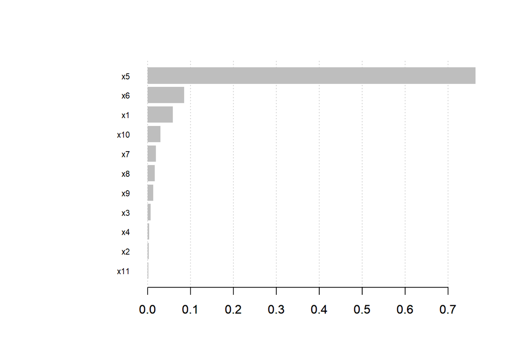

```r
xgb.importance(model = new_data_xgb) %>%
  xgb.plot.importance(top_n = 11)
```

### 第三次

```r
#資料生成
set.seed(123)
a <- matrix(sample(-2:2,25,replace = T),5,5)
sigmas <- t(a)%*%diag(1,5)%*%a
set.seed(12536)
x <- rmvnorm(n = 100,mean = c(0,0,0,0,0),sigma = sigmas)
set.seed(1783)
x2 <- rmvnorm(n = 100,mean = c(0,0,0,0,0),sigma = diag(1,5))
set.seed(519)
x_11 <- rnorm(n = 100)
set.seed(53)
sd <- rnorm(100,sd = 4)
y <- 10*x[,1]+5*x[,2]-3*x[,3]+4*x[,4]+8*x[,5]+10*x2[,1]+5*x2[,2]-3*x2[,3]+4*x2[,4]+8*x2[,5]+sd
sim <- data.frame(y,x,x2,x_11)


set.seed(17773)
x <- rmvnorm(n = 100,mean = c(0,0,0,0,0),sigma = sigmas)
set.seed(18783)
x2 <- rmvnorm(n = 100,mean = c(0,0,0,0,0),sigma = diag(1,5))
set.seed(5994)
x_11 <- rnorm(n = 100)
set.seed(84)
sd <- rnorm(100,sd = 4)
y <- 10*x[,1]+5*x[,2]-3*x[,3]+4*x[,4]+8*x[,5]+10*x2[,1]+5*x2[,2]-3*x2[,3]+4*x2[,4]+8*x2[,5]+sd
sim_2 <- data.frame(y,x,x2,x_11)


set.seed(162752)
x <- rmvnorm(n = 100,mean = c(0,0,0,0,0),sigma = sigmas)
set.seed(1583)
x2 <- rmvnorm(n = 100,mean = c(0,0,0,0,0),sigma = diag(1,5))
set.seed(459)
x_11 <- rnorm(n = 100)
set.seed(94)
sd <- rnorm(100,sd = 4)
y <- 10*x[,1]+5*x[,2]-3*x[,3]+4*x[,4]+8*x[,5]+10*x2[,1]+5*x2[,2]-3*x2[,3]+4*x2[,4]+8*x2[,5]+sd
sim_3 <- data.frame(y,x,x2,x_11)



names(sim) <- c("y",paste0("x",1:11))
names(sim_2) <- c("y",paste0("x",1:11))
names(sim_3) <- c("y",paste0("x",1:11))
```

#### use p-value to Variable Selection

```r
(old_data_lm <- lm(y~.,data = sim)) %>% summary()
```

```
##
## Call:
## lm(formula = y ~ ., data = sim)
##
## Residuals:
##     Min      1Q  Median      3Q     Max
## -6.7195 -2.9448  0.0233  2.2516  8.0781
##
## Coefficients:
##             Estimate Std. Error t value Pr(>|t|)
## (Intercept)  -0.1992     0.4030  -0.494    0.622
## x1           10.6168     0.6499  16.335  < 2e-16 ***
## x2            4.8127     1.1258   4.275 4.84e-05 ***
## x3           -3.3878     0.4930  -6.872 8.71e-10 ***
## x4            4.0600     0.9271   4.379 3.27e-05 ***
## x5            7.6922     0.5586  13.772  < 2e-16 ***
## x6           10.2503     0.4405  23.271  < 2e-16 ***
## x7            4.2699     0.4092  10.436  < 2e-16 ***
## x8           -3.3060     0.3925  -8.423 6.32e-13 ***
## x9            4.5056     0.4179  10.781  < 2e-16 ***
## x10           8.2486     0.4048  20.379  < 2e-16 ***
## x11          -0.3392     0.3952  -0.858    0.393
## ---
## Signif. codes:  0 '***' 0.001 '**' 0.01 '*' 0.05 '.' 0.1 ' ' 1
##
## Residual standard error: 3.91 on 88 degrees of freedom
## Multiple R-squared:  0.991,  Adjusted R-squared:  0.9898
## F-statistic: 877.4 on 11 and 88 DF,  p-value: < 2.2e-16
```

```r
old_data_lm %>% ols_step_forward_p()
```

```
##
##                              Selection Summary
## ----------------------------------------------------------------------------
##         Variable                  Adj.
## Step    Entered     R-Square    R-Square      C(p)         AIC        RMSE
## ----------------------------------------------------------------------------
##    1    x5            0.7096      0.7067    2731.9701    896.7323    21.0063
##    2    x1            0.8708      0.8681    1164.7822    817.7909    14.0869
##    3    x6            0.9134      0.9107     751.2266    779.7245    11.5894
##    4    x10           0.9501      0.9480     396.1059    726.6435     8.8456
##    5    x9            0.9632      0.9613     270.3242    698.1447     7.6348
##    6    x8            0.9748      0.9732     159.4650    662.3163     6.3530
##    7    x7            0.9840      0.9827      72.2483    619.1455     5.0961
##    8    x3            0.9888      0.9878      26.9611    585.1000     4.2790
##    9    x11           0.9890      0.9879      27.1783    585.4503     4.2674
## ----------------------------------------------------------------------------
```

```r
(old_data_lm %<>% ols_step_forward_aic())
```

```
##
##                            Selection Summary
## -----------------------------------------------------------------------
## Variable       AIC        Sum Sq         RSS        R-Sq      Adj. R-Sq
## -----------------------------------------------------------------------
## x5           896.732    105689.487    43244.114    0.70964      0.70668
## x1           817.791    129684.839    19248.762    0.87076      0.86809
## x6           779.724    136039.339    12894.262    0.91342      0.91072
## x10          726.644    141500.277     7433.324    0.95009      0.94799
## x9           698.145    143454.261     5479.341    0.96321      0.96125
## x8           662.316    145180.055     3753.546    0.97480      0.97317
## x7           619.146    146544.319     2389.282    0.98396      0.98274
## x3           585.100    147267.415     1666.186    0.98881      0.98783
## -----------------------------------------------------------------------
```

```r
md <- formula(y~x1+x3+x5+x6+x7+x8+x9+x10+x11)
VS <- c(1,3,5,6,7,8,9,10,11)+1
```

##### old data

###### regression

```r
old_data_lm$model %>% summary()
```

```
##
## Call:
## lm(formula = paste(response, "~", paste(preds, collapse = " + ")),
##     data = l)
##
## Residuals:
##     Min      1Q  Median      3Q     Max
## -9.2827 -3.0400 -0.0915  2.8541  8.9138
##
## Coefficients:
##             Estimate Std. Error t value Pr(>|t|)
## (Intercept)  -0.3641     0.4387  -0.830    0.409
## x5           10.0255     0.1713  58.523  < 2e-16 ***
## x1           12.8177     0.3563  35.971  < 2e-16 ***
## x6           10.1580     0.4802  21.155  < 2e-16 ***
## x10           8.0318     0.4275  18.786  < 2e-16 ***
## x9            4.2732     0.4527   9.440 3.80e-15 ***
## x8           -3.5069     0.4250  -8.252 1.15e-12 ***
## x7            4.1351     0.4400   9.399 4.62e-15 ***
## x3           -1.4190     0.2258  -6.284 1.12e-08 ***
## ---
## Signif. codes:  0 '***' 0.001 '**' 0.01 '*' 0.05 '.' 0.1 ' ' 1
##
## Residual standard error: 4.279 on 91 degrees of freedom
## Multiple R-squared:  0.9888, Adjusted R-squared:  0.9878
## F-statistic:  1005 on 8 and 91 DF,  p-value: < 2.2e-16
```

```r
print("train MSE")
```

```
## [1] "train MSE"
```

```r
label  <- old_data_lm$model %>% predict(sim)
mean((sim$y-label)^2)
```

```
## [1] 16.66186
```

```r
print("test MSE")
```

```
## [1] "test MSE"
```

```r
label  <- old_data_lm$model %>% predict(sim_3)
mean((sim_3$y-label)^2)
```

```
## [1] 25.95975
```

###### XGboost

```r
old_data_xgb <- xgboost(data = data.matrix(sim[,VS]),
label = sim[,"y"],
# eta = 0.5,
# max_depth = 10,
nround=25,
# subsample = 0.7,
# colsample_bytree = 0.7,
objective = "reg:squarederror",
verbose = 0
)
print("train MSE")
```

```
## [1] "train MSE"
```

```r
label  <- predict(old_data_xgb,xgb.DMatrix(data.matrix(sim[,VS])))
mean((sim$y-label)^2)
```

```
## [1] 0.1270685
```

```r
print("test MSE")
```

```
## [1] "test MSE"
```

```r
label  <- predict(old_data_xgb,xgb.DMatrix(data.matrix(sim_3[,VS])))
mean((sim_3$y-label)^2)
```

```
## [1] 325.1187
```

```r
xgb.importance(model = old_data_xgb)
```

| Feature | Gain | Cover | Frequency |
| --- | --- | --- | --- |
| x5 | 0.796171747 | 0.38026552 | 0.20603908 |
| x1 | 0.128747862 | 0.18844636 | 0.29484902 |
| x10 | 0.030323985 | 0.12508073 | 0.09236234 |
| x3 | 0.012279085 | 0.05008970 | 0.11367673 |
| x9 | 0.010005202 | 0.05281665 | 0.04973357 |
| x6 | 0.009488018 | 0.11302476 | 0.11722913 |
| x8 | 0.007399664 | 0.01607463 | 0.02664298 |
| x7 | 0.004369845 | 0.04700395 | 0.06216696 |
| x11 | 0.001214593 | 0.02719770 | 0.03730018 |

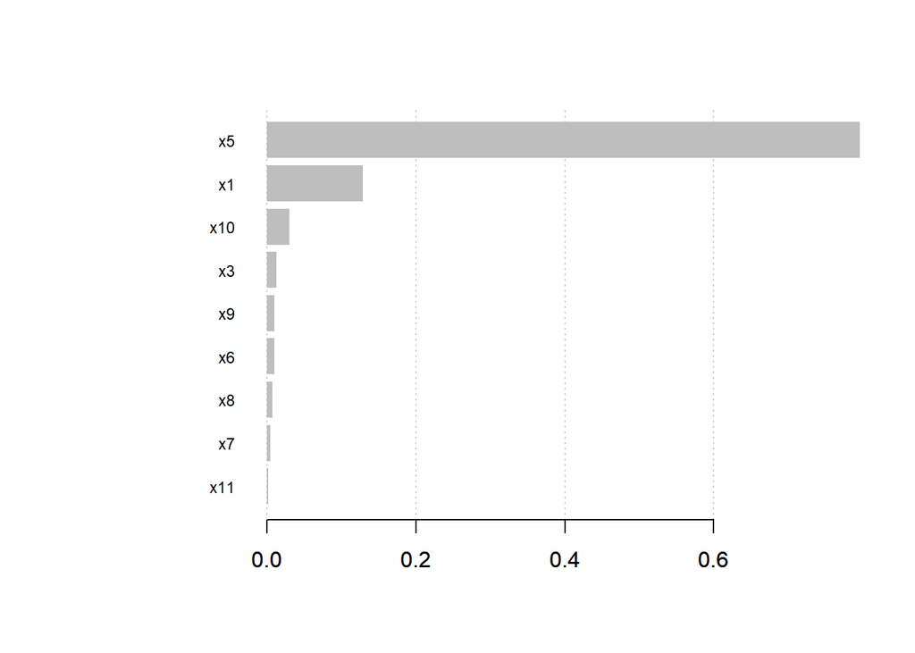

```r
xgb.importance(model = old_data_xgb) %>%
  xgb.plot.importance(top_n = 11)
```

##### new data

###### regression

```r
new_data_lm <- lm(md,data = sim_2)



new_data_lm %>% summary()
```

```
##
## Call:
## lm(formula = md, data = sim_2)
##
## Residuals:
##     Min      1Q  Median      3Q     Max
## -8.9874 -2.5233 -0.2476  2.9722  7.2675
##
## Coefficients:
##             Estimate Std. Error t value Pr(>|t|)
## (Intercept)   0.5541     0.4255   1.302    0.196
## x1           13.1538     0.3524  37.322  < 2e-16 ***
## x3           -1.2472     0.2097  -5.947 5.13e-08 ***
## x5           10.1325     0.1839  55.088  < 2e-16 ***
## x6            9.7650     0.4109  23.767  < 2e-16 ***
## x7            5.3231     0.3960  13.443  < 2e-16 ***
## x8           -3.4254     0.4998  -6.853 8.73e-10 ***
## x9            4.4816     0.3976  11.273  < 2e-16 ***
## x10           7.4305     0.3862  19.242  < 2e-16 ***
## x11           0.6647     0.3964   1.677    0.097 .
## ---
## Signif. codes:  0 '***' 0.001 '**' 0.01 '*' 0.05 '.' 0.1 ' ' 1
##
## Residual standard error: 3.873 on 90 degrees of freedom
## Multiple R-squared:  0.9893, Adjusted R-squared:  0.9882
## F-statistic: 922.7 on 9 and 90 DF,  p-value: < 2.2e-16
```

```r
print("train MSE")
```

```
## [1] "train MSE"
```

```r
label  <- new_data_lm %>% predict(sim_2)
mean((sim_2$y-label)^2)
```

```
## [1] 13.49723
```

```r
print("test MSE")
```

```
## [1] "test MSE"
```

```r
label  <- new_data_lm %>% predict(sim_3)
mean((sim_3$y-label)^2)
```

```
## [1] 25.24515
```

###### XGboost

```r
new_data_xgb <- xgboost(data = data.matrix(sim_2[,VS]),
label = sim_2[,"y"],
# eta = 0.5,
# max_depth = 10,
nround=25,
# subsample = 0.7,
# colsample_bytree = 0.7,
objective = "reg:squarederror",
verbose = 0
)
print("train MSE")
```

```
## [1] "train MSE"
```

```r
label  <- predict(new_data_xgb,xgb.DMatrix(data.matrix(sim_2[,VS])))
mean((sim_2$y-label)^2)
```

```
## [1] 0.09285536
```

```r
print("test MSE")
```

```
## [1] "test MSE"
```

```r
label  <- predict(new_data_xgb,xgb.DMatrix(data.matrix(sim_3[,VS])))
mean((sim_3$y-label)^2)
```

```
## [1] 420.8808
```

```r
xgb.importance(model = new_data_xgb)
```

| Feature | Gain | Cover | Frequency |
| --- | --- | --- | --- |
| x5 | 0.782009196 | 0.38444169 | 0.21180556 |
| x1 | 0.101377100 | 0.21771433 | 0.25000000 |
| x6 | 0.055114472 | 0.11887246 | 0.14756944 |
| x11 | 0.017265283 | 0.02826134 | 0.04513889 |
| x10 | 0.015783153 | 0.06650157 | 0.06770833 |
| x3 | 0.009374205 | 0.03037366 | 0.08680556 |
| x7 | 0.008060853 | 0.03576371 | 0.05555556 |
| x8 | 0.006788931 | 0.06781266 | 0.08506944 |
| x9 | 0.004226806 | 0.05025858 | 0.05034722 |

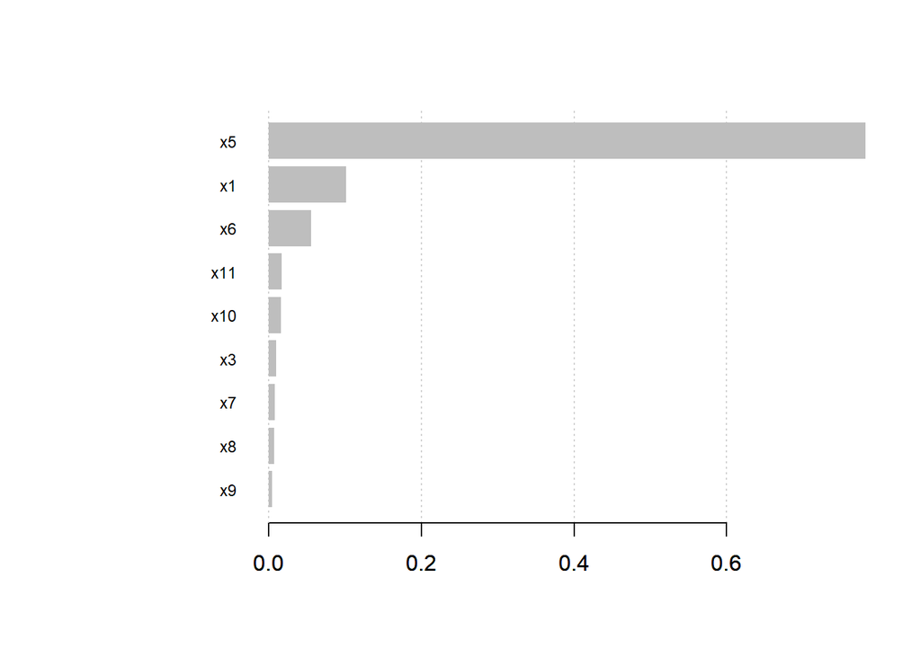

```r
xgb.importance(model = new_data_xgb) %>%
  xgb.plot.importance(top_n = 11)
```

#### use Gain to Variable Selection

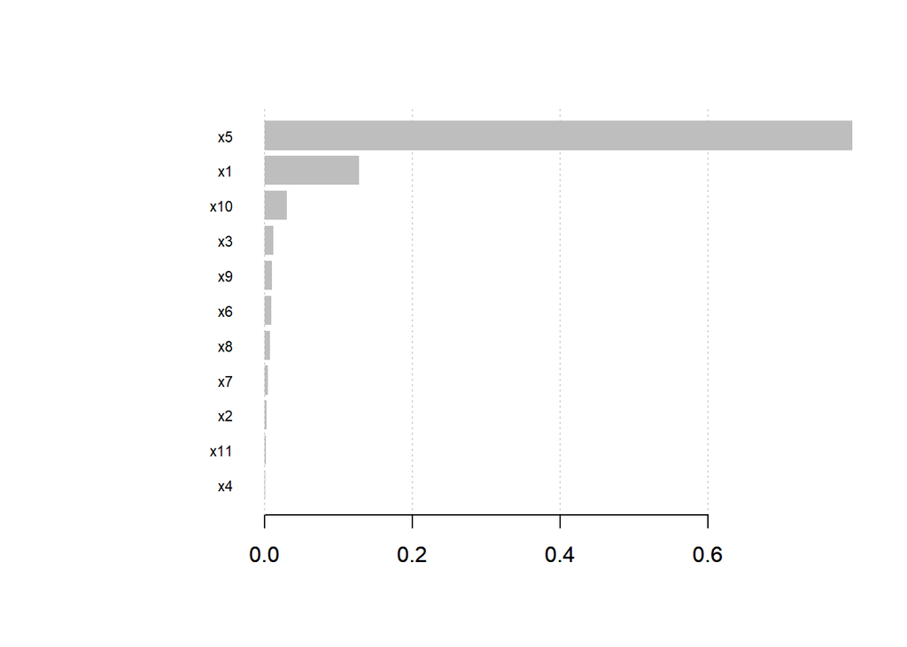

```r
xgb_test <- xgboost(data = data.matrix(sim[,-1]),
label = sim[,"y"],
# eta = 0.5,
# max_depth = 10,
nround=25,
# subsample = 0.7,
# colsample_bytree = 0.7,
objective = "reg:squarederror",
verbose = 0
)

xgb.importance(model = xgb_test) %>%
  xgb.plot.importance(top_n = 11)
```

```r
md <- formula(y~x1+x2+x3+x5+x6+x8+x7+x9+x10)
VS <- c(1,2,3,5,6,7,8,9,10)+1
```

##### old data

###### regression

```r
old_data_lm <- lm(md,data = sim)



old_data_lm %>% summary()
```

```
##
## Call:
## lm(formula = md, data = sim)
##
## Residuals:
##     Min      1Q  Median      3Q     Max
## -9.2652 -3.0416 -0.1053  2.8686  8.9171
##
## Coefficients:
##             Estimate Std. Error t value Pr(>|t|)
## (Intercept) -0.36489    0.44157  -0.826    0.411
## x1          12.80657    0.45003  28.457  < 2e-16 ***
## x2           0.01068    0.26132   0.041    0.967
## x3          -1.42022    0.22905  -6.200 1.67e-08 ***
## x5          10.02949    0.19744  50.797  < 2e-16 ***
## x6          10.15710    0.48334  21.014  < 2e-16 ***
## x8          -3.50802    0.42815  -8.193 1.63e-12 ***
## x7           4.13371    0.44377   9.315 7.60e-15 ***
## x9           4.27188    0.45633   9.361 6.08e-15 ***
## x10          8.02940    0.43396  18.503  < 2e-16 ***
## ---
## Signif. codes:  0 '***' 0.001 '**' 0.01 '*' 0.05 '.' 0.1 ' ' 1
##
## Residual standard error: 4.303 on 90 degrees of freedom
## Multiple R-squared:  0.9888, Adjusted R-squared:  0.9877
## F-statistic: 883.9 on 9 and 90 DF,  p-value: < 2.2e-16
```

```r
print("train MSE")
```

```
## [1] "train MSE"
```

```r
label  <- old_data_lm %>% predict(sim)
mean((sim$y-label)^2)
```

```
## [1] 16.66155
```

```r
print("test MSE")
```

```
## [1] "test MSE"
```

```r
label  <- old_data_lm %>% predict(sim_3)
mean((sim_3$y-label)^2)
```

```
## [1] 25.92164
```

###### XGboost

```r
old_data_xgb <- xgboost(data = data.matrix(sim[,VS]),
label = sim[,"y"],
# eta = 0.5,
# max_depth = 10,
nround=25,
# subsample = 0.7,
# colsample_bytree = 0.7,
objective = "reg:squarederror",
verbose = 0
)
print("train MSE")
```

```
## [1] "train MSE"
```

```r
label  <- predict(old_data_xgb,xgb.DMatrix(data.matrix(sim[,VS])))
mean((sim$y-label)^2)
```

```
## [1] 0.104573
```

```r
print("test MSE")
```

```
## [1] "test MSE"
```

```r
label  <- predict(old_data_xgb,xgb.DMatrix(data.matrix(sim_3[,VS])))
mean((sim_3$y-label)^2)
```

```
## [1] 343.5933
```

```r
xgb.importance(model = old_data_xgb)
```

| Feature | Gain | Cover | Frequency |
| --- | --- | --- | --- |
| x5 | 0.793474825 | 0.36397059 | 0.19107143 |
| x1 | 0.127333834 | 0.17913783 | 0.29464286 |
| x10 | 0.030145356 | 0.11079873 | 0.09285714 |
| x3 | 0.012446440 | 0.05853518 | 0.11071429 |
| x9 | 0.010230391 | 0.05608420 | 0.05714286 |
| x6 | 0.009470712 | 0.12435121 | 0.10000000 |
| x8 | 0.009067815 | 0.03013264 | 0.03571429 |
| x7 | 0.004806843 | 0.05038927 | 0.05714286 |
| x2 | 0.003023784 | 0.02660035 | 0.06071429 |

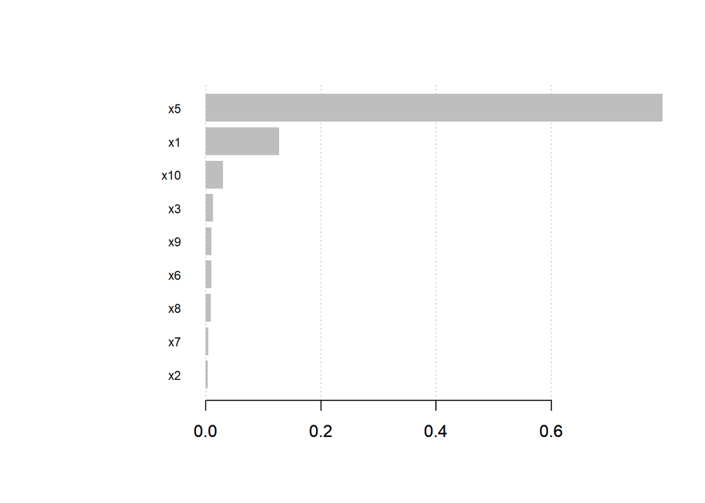

```r
xgb.importance(model = old_data_xgb) %>%
  xgb.plot.importance(top_n = 11)
```

##### new data

###### regression

```r
new_data_lm <- lm(md,data = sim_2)



new_data_lm %>% summary()
```

```
##
## Call:
## lm(formula = md, data = sim_2)
##
## Residuals:
##     Min      1Q  Median      3Q     Max
## -9.9234 -2.7096  0.1051  2.5909  7.1738
##
## Coefficients:
##             Estimate Std. Error t value Pr(>|t|)
## (Intercept)   0.4709     0.4288   1.098    0.275
## x1           12.8603     0.4082  31.501  < 2e-16 ***
## x2            0.2076     0.1996   1.040    0.301
## x3           -1.2143     0.2102  -5.778 1.07e-07 ***
## x5           10.2192     0.1969  51.909  < 2e-16 ***
## x6            9.8623     0.4123  23.920  < 2e-16 ***
## x8           -3.2078     0.4860  -6.601 2.76e-09 ***
## x7            5.1941     0.4015  12.938  < 2e-16 ***
## x9            4.4521     0.4009  11.104  < 2e-16 ***
## x10           7.3331     0.3835  19.120  < 2e-16 ***
## ---
## Signif. codes:  0 '***' 0.001 '**' 0.01 '*' 0.05 '.' 0.1 ' ' 1
##
## Residual standard error: 3.909 on 90 degrees of freedom
## Multiple R-squared:  0.9891, Adjusted R-squared:  0.988
## F-statistic: 905.3 on 9 and 90 DF,  p-value: < 2.2e-16
```

```r
print("train MSE")
```

```
## [1] "train MSE"
```

```r
label  <- new_data_lm %>% predict(sim_2)
mean((sim_2$y-label)^2)
```

```
## [1] 13.75365
```

```r
print("test MSE")
```

```
## [1] "test MSE"
```

```r
label  <- new_data_lm %>% predict(sim_3)
mean((sim_3$y-label)^2)
```

```
## [1] 23.58798
```

###### XGboost

```r
new_data_xgb <- xgboost(data = data.matrix(sim_2[,VS]),
label = sim_2[,"y"],
# eta = 0.5,
# max_depth = 10,
nround=25,
# subsample = 0.7,
# colsample_bytree = 0.7,
objective = "reg:squarederror",
verbose = 0
)
print("train MSE")
```

```
## [1] "train MSE"
```

```r
label  <- predict(new_data_xgb,xgb.DMatrix(data.matrix(sim_2[,VS])))
mean((sim_2$y-label)^2)
```

```
## [1] 0.1266111
```

```r
print("test MSE")
```

```
## [1] "test MSE"
```

```r
label  <- predict(new_data_xgb,xgb.DMatrix(data.matrix(sim_3[,VS])))
mean((sim_3$y-label)^2)
```

```
## [1] 401.402
```

```r
xgb.importance(model = new_data_xgb)
```

| Feature | Gain | Cover | Frequency |
| --- | --- | --- | --- |
| x5 | 0.793941429 | 0.34719815 | 0.19544592 |
| x1 | 0.087779775 | 0.21569902 | 0.27514231 |
| x6 | 0.060606833 | 0.12868284 | 0.12523719 |
| x2 | 0.015944558 | 0.06152513 | 0.08538899 |
| x10 | 0.015117804 | 0.07676199 | 0.07210626 |
| x7 | 0.008984308 | 0.03848931 | 0.06451613 |
| x3 | 0.008150200 | 0.03249567 | 0.07400380 |
| x8 | 0.005047808 | 0.04484402 | 0.05882353 |
| x9 | 0.004427286 | 0.05430387 | 0.04933586 |

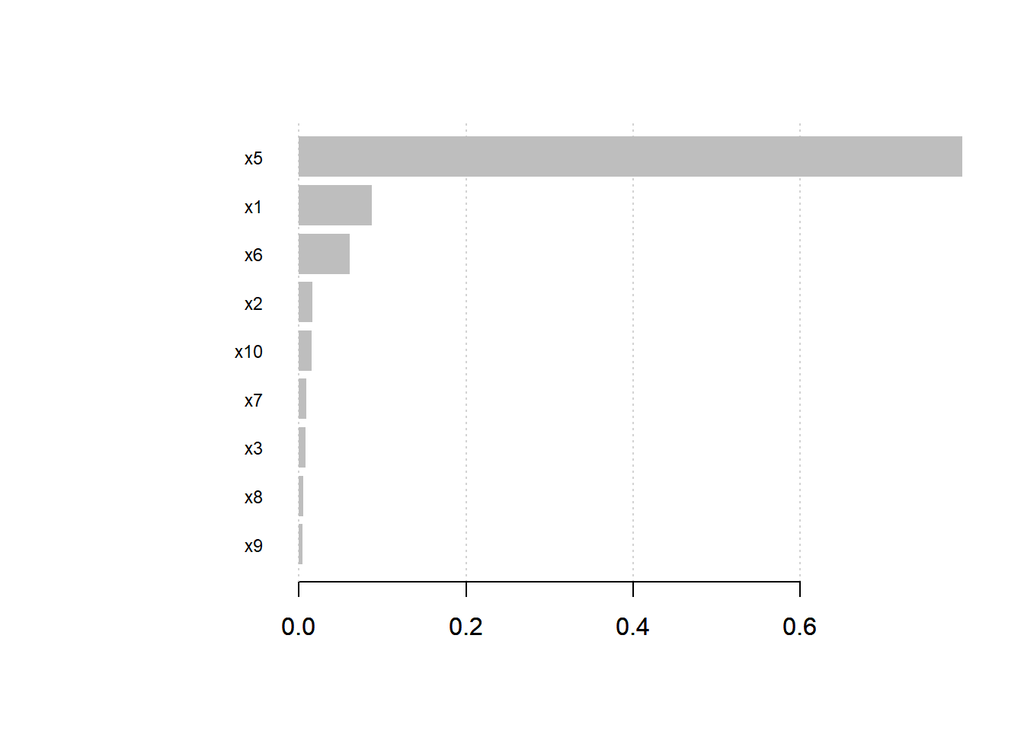

```r
xgb.importance(model = new_data_xgb) %>%
  xgb.plot.importance(top_n = 11)
```

## 資料二(一般項加交互作用項)

regression的表現比資料一差。  
XGboost還是差不多。

$x_{1 \sim 10}\sim MN(\mu , \Sigma )$ $\mu=(0,0,0,0,0,0,0,0,0,0)$
$$\Sigma = \begin{pmatrix}
1 & 0 & 0 & 0 & 0 & 0 & 0 & 0 & 0 & 0\\
0 & 1& 0 & 0 & 0 & 0 & 0 & 0 & 0 & 0\\
0 & 0& 1 & 0 & 0 & 0 & 0 & 0 & 0 & 0\\
0 & 0& 0 & 1 & 0 & 0 & 0 & 0 & 0 & 0\\
0 & 0& 0 & 0 & 1 & 0 & 0 & 0 & 0 & 0\\
0 & 0& 0 & 0 & 0 & 1 & 0 & 0 & 0 & 0\\
0 & 0& 0 & 0 & 0 & 0 & 1 & 0 & 0 & 0\\
0 & 0& 0 & 0 & 0 & 0 & 0 & 1 & 0 & 0\\
0 & 0& 0 & 0 & 0 & 0 & 0 & 0 & 1 & 0\\
0 & 0& 0 & 0 & 0 & 0 & 0 & 0 & 0 & 1
\end{pmatrix}$$

$x_{11} \sim N(0,1)$

$y=10x_1+5x_2-3x_3+4x_4+8x_5-7x_6+9x_7-2x_8+5x_9-4x_{10}+10x_1x_2-7x_3x_4+\epsilon$

$\epsilon \sim N(0,4)$

### 第一次

```r
set.seed(1423)
x <- rmvnorm(n = 100,mean = c(0,0,0,0,0,0,0,0,0,0),sigma = diag(1,10))
set.seed(597)
x_11 <- rnorm(n = 100)
set.seed(55)
sd <- rnorm(100,sd = 4)
y <- 10*x[,1]+5*x[,2]-3*x[,3]+4*x[,4]+8*x[,5]-7*x[,6]+9*x[,7]-2*x[,8]+5*x[,9]-4*x[,10]+10*x[,1]*x[,2]-7*x[,3]*x[,4]+sd
sim <- data.frame(y,x,x_11)


set.seed(1232)
x <- rmvnorm(n = 100,mean = c(0,0,0,0,0,0,0,0,0,0),sigma = diag(1,10))
set.seed(599)
x_11 <- rnorm(n = 100)
set.seed(57)
sd <- rnorm(100,sd = 4)
y <- 10*x[,1]+5*x[,2]-3*x[,3]+4*x[,4]+8*x[,5]-7*x[,6]+9*x[,7]-2*x[,8]+5*x[,9]-4*x[,10]+10*x[,1]*x[,2]-7*x[,3]*x[,4]+sd
sim_2 <- data.frame(y,x,x_11)


set.seed(125332)
x <- rmvnorm(n = 100,mean = c(0,0,0,0,0,0,0,0,0,0),sigma = diag(1,10))
set.seed(56699)
x_11 <- rnorm(n = 100)
set.seed(5247)
sd <- rnorm(100,sd = 4)
y <- 10*x[,1]+5*x[,2]-3*x[,3]+4*x[,4]+8*x[,5]-7*x[,6]+9*x[,7]-2*x[,8]+5*x[,9]-4*x[,10]+10*x[,1]*x[,2]-7*x[,3]*x[,4]+sd
sim_3 <- data.frame(y,x,x_11)





names(sim) <- c("y",paste0("x",1:11))
names(sim_2) <- c("y",paste0("x",1:11))
names(sim_3) <- c("y",paste0("x",1:11))
```

#### use p-value to Variable Selection

```r
(old_data_lm <- lm(y~.,data = sim)) %>% summary()
```

```
##
## Call:
## lm(formula = y ~ ., data = sim)
##
## Residuals:
##     Min      1Q  Median      3Q     Max
## -50.924  -5.563   1.418   5.541  28.100
##
## Coefficients:
##             Estimate Std. Error t value Pr(>|t|)
## (Intercept)   -1.287      1.341  -0.960 0.339872
## x1            12.800      1.479   8.656 2.10e-13 ***
## x2             7.595      1.297   5.855 8.08e-08 ***
## x3            -5.734      1.417  -4.045 0.000112 ***
## x4             3.849      1.141   3.372 0.001110 **
## x5             6.341      1.252   5.065 2.23e-06 ***
## x6            -5.088      1.260  -4.038 0.000115 ***
## x7            11.117      1.211   9.180 1.75e-14 ***
## x8            -1.164      1.188  -0.980 0.329599
## x9             5.570      1.303   4.274 4.85e-05 ***
## x10           -4.614      1.125  -4.102 9.13e-05 ***
## x11            0.898      1.246   0.721 0.473118
## ---
## Signif. codes:  0 '***' 0.001 '**' 0.01 '*' 0.05 '.' 0.1 ' ' 1
##
## Residual standard error: 12.35 on 88 degrees of freedom
## Multiple R-squared:  0.7336, Adjusted R-squared:  0.7003
## F-statistic: 22.03 on 11 and 88 DF,  p-value: < 2.2e-16
```

```r
old_data_lm %>% ols_step_forward_p()
```

```
##
##                              Selection Summary
## ---------------------------------------------------------------------------
##         Variable                  Adj.
## Step    Entered     R-Square    R-Square      C(p)        AIC        RMSE
## ---------------------------------------------------------------------------
##    1    x7            0.1693      0.1609    178.3475    893.5113    20.6707
##    2    x1            0.3033      0.2889    136.1076    877.9264    19.0282
##    3    x2            0.4173      0.3991    100.4503    862.0555    17.4921
##    4    x9            0.5010      0.4800     74.8201    848.5572    16.2728
##    5    x5            0.5602      0.5368     57.2655    837.9280    15.3580
##    6    x6            0.6046      0.5790     44.6060    829.2902    14.6406
##    7    x3            0.6521      0.6256     30.9050    818.4823    13.8068
##    8    x10           0.6963      0.6696     18.3000    806.8883    12.9702
##    9    x4            0.7288      0.7017      9.5683    797.5719    12.3246
## ---------------------------------------------------------------------------
```

```r
(old_data_lm %<>% ols_step_forward_aic())
```

```
##
##                           Selection Summary
## ----------------------------------------------------------------------
## Variable       AIC       Sum Sq         RSS        R-Sq      Adj. R-Sq
## ----------------------------------------------------------------------
## x7           893.511     8536.419    41873.383    0.16934      0.16086
## x1           877.926    15288.704    35121.098    0.30329      0.28892
## x2           862.055    21036.311    29373.491    0.41731      0.39910
## x9           848.557    25253.472    25156.330    0.50096      0.47995
## x5           837.928    28238.071    22171.731    0.56017      0.53678
## x6           829.290    30475.536    19934.266    0.60456      0.57904
## x3           818.482    32871.963    17537.839    0.65209      0.62562
## x10          806.888    35101.111    15308.691    0.69632      0.66962
## x4           797.572    36739.079    13670.723    0.72881      0.70169
## ----------------------------------------------------------------------
```

```r
md <- formula(y~x1+x2+x3+x4+x5+x6+x7+x9+x10)
VS <- c(1,2,3,4,5,6,7,9,10)+1
```

##### old data

###### regression

```r
old_data_lm$model %>% summary()
```

```
##
## Call:
## lm(formula = paste(response, "~", paste(preds, collapse = " + ")),
##     data = l)
##
## Residuals:
##     Min      1Q  Median      3Q     Max
## -50.976  -5.602   1.421   5.415  28.694
##
## Coefficients:
##             Estimate Std. Error t value Pr(>|t|)
## (Intercept)   -1.253      1.335  -0.939 0.350461
## x7            11.164      1.204   9.271 9.39e-15 ***
## x1            13.137      1.449   9.065 2.52e-14 ***
## x2             7.704      1.283   6.005 3.98e-08 ***
## x9             5.733      1.289   4.446 2.49e-05 ***
## x5             6.381      1.243   5.133 1.63e-06 ***
## x6            -4.966      1.253  -3.963 0.000148 ***
## x3            -5.808      1.411  -4.117 8.49e-05 ***
## x10           -4.613      1.118  -4.126 8.21e-05 ***
## x4             3.724      1.134   3.284 0.001460 **
## ---
## Signif. codes:  0 '***' 0.001 '**' 0.01 '*' 0.05 '.' 0.1 ' ' 1
##
## Residual standard error: 12.32 on 90 degrees of freedom
## Multiple R-squared:  0.7288, Adjusted R-squared:  0.7017
## F-statistic: 26.87 on 9 and 90 DF,  p-value: < 2.2e-16
```

```r
print("train MSE")
```

```
## [1] "train MSE"
```

```r
label  <- old_data_lm$model %>% predict(sim)
mean((sim$y-label)^2)
```

```
## [1] 136.7072
```

```r
print("test MSE")
```

```
## [1] "test MSE"
```

```r
label  <- old_data_lm$model %>% predict(sim_3)
mean((sim_3$y-label)^2)
```

```
## [1] 211.9405
```

###### XGboost

```r
old_data_xgb <- xgboost(data = data.matrix(sim[,VS]),
label = sim[,"y"],
# eta = 0.5,
# max_depth = 10,
nround=25,
# subsample = 0.7,
# colsample_bytree = 0.7,
objective = "reg:squarederror",
verbose = 0
)
print("train MSE")
```

```
## [1] "train MSE"
```

```r
label  <- predict(old_data_xgb,xgb.DMatrix(data.matrix(sim[,VS])))
mean((sim$y-label)^2)
```

```
## [1] 0.1355353
```

```r
print("test MSE")
```

```
## [1] "test MSE"
```

```r
label  <- predict(old_data_xgb,xgb.DMatrix(data.matrix(sim_3[,VS])))
mean((sim_3$y-label)^2)
```

```
## [1] 297.1667
```

```r
xgb.importance(model = old_data_xgb)
```

| Feature | Gain | Cover | Frequency |
| --- | --- | --- | --- |
| x7 | 0.226398236 | 0.19411185 | 0.11377246 |
| x1 | 0.214217502 | 0.17079870 | 0.23353293 |
| x2 | 0.177411626 | 0.23975208 | 0.17764471 |
| x6 | 0.130485655 | 0.06550218 | 0.09580838 |
| x5 | 0.106119062 | 0.07557402 | 0.06786427 |
| x9 | 0.067948968 | 0.06599521 | 0.05988024 |
| x4 | 0.038127842 | 0.07979997 | 0.10578842 |
| x10 | 0.032591408 | 0.05641640 | 0.07784431 |
| x3 | 0.006699701 | 0.05204958 | 0.06786427 |

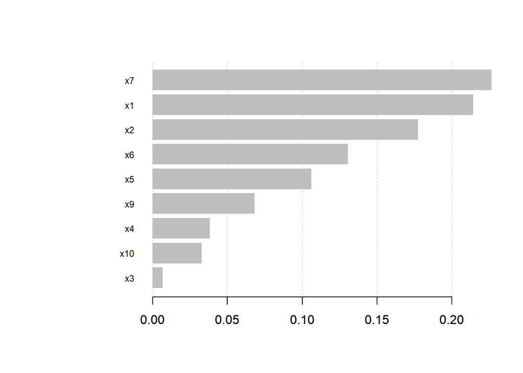

```r
xgb.importance(model = old_data_xgb) %>%
  xgb.plot.importance(top_n = 11)
```

##### new data

###### regression

```r
new_data_lm <- lm(md,data = sim_2)



new_data_lm %>% summary()
```

```
##
## Call:
## lm(formula = md, data = sim_2)
##
## Residuals:
##     Min      1Q  Median      3Q     Max
## -40.368  -5.606  -0.538   8.070  29.931
##
## Coefficients:
##             Estimate Std. Error t value Pr(>|t|)
## (Intercept)  -0.5793     1.3675  -0.424 0.672875
## x1           10.5581     1.3512   7.814 9.83e-12 ***
## x2            5.6832     1.2530   4.536 1.76e-05 ***
## x3           -1.8617     1.3784  -1.351 0.180193
## x4            2.1289     1.3902   1.531 0.129190
## x5            7.0473     1.3596   5.183 1.33e-06 ***
## x6           -7.9515     1.5106  -5.264 9.52e-07 ***
## x7           10.3659     1.4786   7.011 4.22e-10 ***
## x9            5.0384     1.3193   3.819 0.000246 ***
## x10          -3.1670     1.2664  -2.501 0.014200 *
## ---
## Signif. codes:  0 '***' 0.001 '**' 0.01 '*' 0.05 '.' 0.1 ' ' 1
##
## Residual standard error: 12.92 on 90 degrees of freedom
## Multiple R-squared:  0.7226, Adjusted R-squared:  0.6948
## F-statistic: 26.04 on 9 and 90 DF,  p-value: < 2.2e-16
```

```r
print("train MSE")
```

```
## [1] "train MSE"
```

```r
label  <- new_data_lm %>% predict(sim_2)
mean((sim_2$y-label)^2)
```

```
## [1] 150.1239
```

```r
print("test MSE")
```

```
## [1] "test MSE"
```

```r
label  <- new_data_lm %>% predict(sim_3)
mean((sim_3$y-label)^2)
```

```
## [1] 179.2459
```

###### XGboost

```r
new_data_xgb <- xgboost(data = data.matrix(sim_2[,VS]),
label = sim_2[,"y"],
# eta = 0.5,
# max_depth = 10,
nround=25,
# subsample = 0.7,
# colsample_bytree = 0.7,
objective = "reg:squarederror",
verbose = 0
)
print("train MSE")
```

```
## [1] "train MSE"
```

```r
label  <- predict(new_data_xgb,xgb.DMatrix(data.matrix(sim_2[,VS])))
mean((sim_2$y-label)^2)
```

```
## [1] 0.1007842
```

```r
print("test MSE")
```

```
## [1] "test MSE"
```

```r
label  <- predict(new_data_xgb,xgb.DMatrix(data.matrix(sim_3[,VS])))
mean((sim_3$y-label)^2)
```

```
## [1] 240.3676
```

```r
xgb.importance(model = new_data_xgb)
```

| Feature | Gain | Cover | Frequency |
| --- | --- | --- | --- |
| x1 | 0.329471446 | 0.17902098 | 0.23649907 |
| x2 | 0.228441796 | 0.22440559 | 0.15270019 |
| x5 | 0.111407640 | 0.10685315 | 0.09869646 |
| x7 | 0.106262612 | 0.07307692 | 0.10428305 |
| x6 | 0.097402568 | 0.11622378 | 0.09310987 |
| x10 | 0.055173048 | 0.04531469 | 0.06703911 |
| x9 | 0.035765512 | 0.05734266 | 0.06517691 |
| x4 | 0.027413814 | 0.14692308 | 0.11173184 |
| x3 | 0.008661565 | 0.05083916 | 0.07076350 |

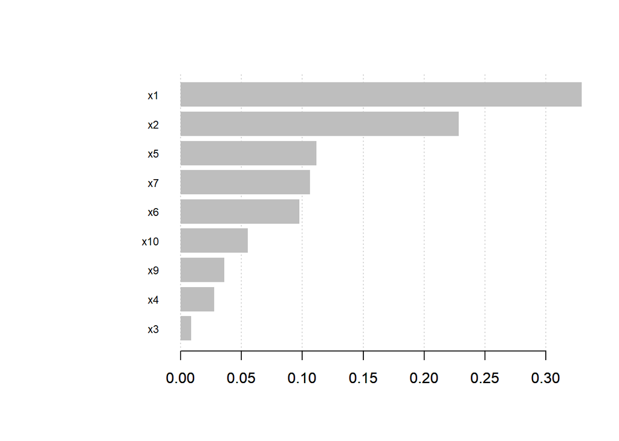

```r
xgb.importance(model = new_data_xgb) %>%
  xgb.plot.importance(top_n = 11)
```

#### use Gain to Variable Selection

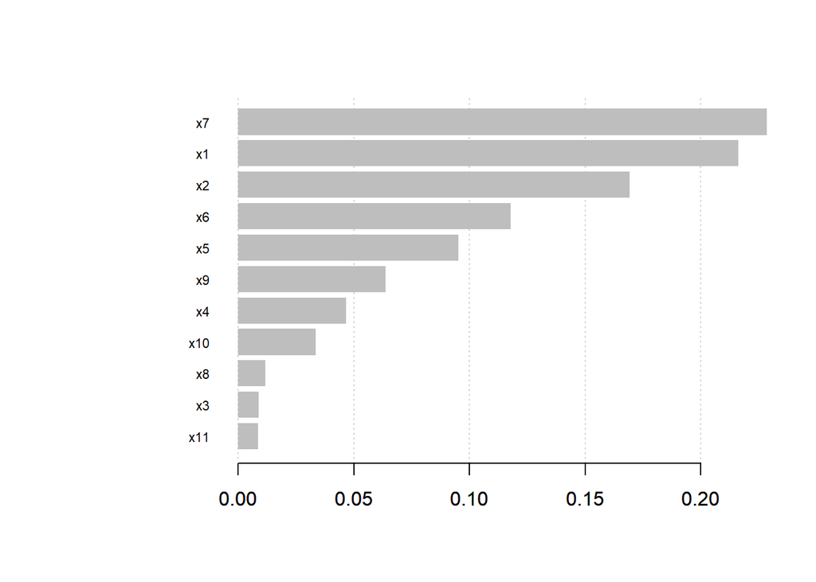

```r
xgb_test <- xgboost(data = data.matrix(sim[,-1]),
label = sim[,"y"],
# eta = 0.5,
# max_depth = 10,
nround=25,
# subsample = 0.7,
# colsample_bytree = 0.7,
objective = "reg:squarederror",
verbose = 0
)

xgb.importance(model = xgb_test) %>%
  xgb.plot.importance(top_n = 11)
```

```r
md <- formula(y~x1+x2+x4+x5+x6+x7+x8+x9+x10)
VS <- c(1,2,4,5,6,7,8,9,10)+1
```

##### old data

###### regression

```r
old_data_lm <- lm(md,data = sim)



old_data_lm %>% summary()
```

```
##
## Call:
## lm(formula = md, data = sim)
##
## Residuals:
##     Min      1Q  Median      3Q     Max
## -51.278  -6.432   0.968   7.865  30.072
##
## Coefficients:
##             Estimate Std. Error t value Pr(>|t|)
## (Intercept)  -0.5762     1.4337  -0.402 0.688684
## x1           11.9903     1.5585   7.693 1.74e-11 ***
## x2            7.2173     1.3950   5.174 1.38e-06 ***
## x4            3.5954     1.2279   2.928 0.004320 **
## x5            6.0449     1.3413   4.507 1.97e-05 ***
## x6           -4.5613     1.3525  -3.373 0.001099 **
## x7           10.8809     1.3044   8.342 8.02e-13 ***
## x8           -1.5239     1.2767  -1.194 0.235735
## x9            5.7782     1.4048   4.113 8.62e-05 ***
## x10          -4.6764     1.2107  -3.862 0.000211 ***
## ---
## Signif. codes:  0 '***' 0.001 '**' 0.01 '*' 0.05 '.' 0.1 ' ' 1
##
## Residual standard error: 13.33 on 90 degrees of freedom
## Multiple R-squared:  0.6828, Adjusted R-squared:  0.651
## F-statistic: 21.52 on 9 and 90 DF,  p-value: < 2.2e-16
```

```r
print("train MSE")
```

```
## [1] "train MSE"
```

```r
label  <- old_data_lm %>% predict(sim)
mean((sim$y-label)^2)
```

```
## [1] 159.9228
```

```r
print("test MSE")
```

```
## [1] "test MSE"
```

```r
label  <- old_data_lm %>% predict(sim_3)
mean((sim_3$y-label)^2)
```

```
## [1] 212.3432
```

###### XGboost

```r
old_data_xgb <- xgboost(data = data.matrix(sim[,VS]),
label = sim[,"y"],
# eta = 0.5,
# max_depth = 10,
nround=25,
# subsample = 0.7,
# colsample_bytree = 0.7,
objective = "reg:squarederror",
verbose = 0
)
print("train MSE")
```

```
## [1] "train MSE"
```

```r
label  <- predict(old_data_xgb,xgb.DMatrix(data.matrix(sim[,VS])))
mean((sim$y-label)^2)
```

```
## [1] 0.1514691
```

```r
print("test MSE")
```

```
## [1] "test MSE"
```

```r
label  <- predict(old_data_xgb,xgb.DMatrix(data.matrix(sim_3[,VS])))
mean((sim_3$y-label)^2)
```

```
## [1] 280.3993
```

```r
xgb.importance(model = old_data_xgb)
```

| Feature | Gain | Cover | Frequency |
| --- | --- | --- | --- |
| x7 | 0.23130056 | 0.20542283 | 0.11727079 |
| x1 | 0.22815866 | 0.20654382 | 0.25373134 |
| x2 | 0.17422378 | 0.22167729 | 0.16204691 |
| x6 | 0.11846557 | 0.06606880 | 0.10447761 |
| x5 | 0.10168608 | 0.08834863 | 0.08528785 |
| x9 | 0.05245535 | 0.06971204 | 0.06823028 |
| x4 | 0.04352352 | 0.04399916 | 0.08742004 |
| x10 | 0.03685318 | 0.07461641 | 0.07675906 |
| x8 | 0.01333331 | 0.02361101 | 0.04477612 |

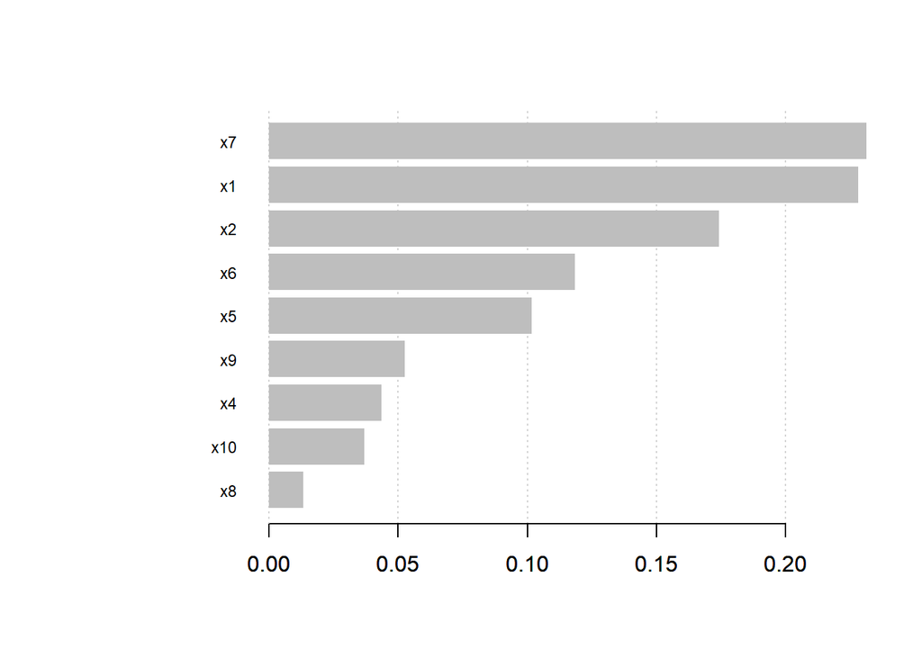

```r
xgb.importance(model = old_data_xgb) %>%
  xgb.plot.importance(top_n = 11)
```

##### new data

###### regression

```r
new_data_lm <- lm(md,data = sim_2)



new_data_lm %>% summary()
```

```
##
## Call:
## lm(formula = md, data = sim_2)
##
## Residuals:
##     Min      1Q  Median      3Q     Max
## -42.094  -5.621  -0.767   7.912  30.457
##
## Coefficients:
##             Estimate Std. Error t value Pr(>|t|)
## (Intercept)  -0.2608     1.3991  -0.186 0.852535
## x1           10.5191     1.3519   7.781 1.15e-11 ***
## x2            5.6947     1.2557   4.535 1.77e-05 ***
## x4            2.2143     1.4058   1.575 0.118739
## x5            6.7930     1.3602   4.994 2.88e-06 ***
## x6           -7.7335     1.5147  -5.106 1.83e-06 ***
## x7           10.4779     1.4765   7.096 2.84e-10 ***
## x8           -1.6883     1.3824  -1.221 0.225158
## x9            5.2391     1.3197   3.970 0.000145 ***
## x10          -3.0494     1.2658  -2.409 0.018030 *
## ---
## Signif. codes:  0 '***' 0.001 '**' 0.01 '*' 0.05 '.' 0.1 ' ' 1
##
## Residual standard error: 12.94 on 90 degrees of freedom
## Multiple R-squared:  0.7215, Adjusted R-squared:  0.6937
## F-statistic: 25.91 on 9 and 90 DF,  p-value: < 2.2e-16
```

```r
print("train MSE")
```

```
## [1] "train MSE"
```

```r
label  <- new_data_lm %>% predict(sim_2)
mean((sim_2$y-label)^2)
```

```
## [1] 150.6698
```

```r
print("test MSE")
```

```
## [1] "test MSE"
```

```r
label  <- new_data_lm %>% predict(sim_3)
mean((sim_3$y-label)^2)
```

```
## [1] 194.3553
```

###### XGboost

```r
new_data_xgb <- xgboost(data = data.matrix(sim_2[,VS]),
label = sim_2[,"y"],
# eta = 0.5,
# max_depth = 10,
nround=25,
# subsample = 0.7,
# colsample_bytree = 0.7,
objective = "reg:squarederror",
verbose = 0
)
print("train MSE")
```

```
## [1] "train MSE"
```

```r
label  <- predict(new_data_xgb,xgb.DMatrix(data.matrix(sim_2[,VS])))
mean((sim_2$y-label)^2)
```

```
## [1] 0.1008834
```

```r
print("test MSE")
```

```
## [1] "test MSE"
```

```r
label  <- predict(new_data_xgb,xgb.DMatrix(data.matrix(sim_3[,VS])))
mean((sim_3$y-label)^2)
```

```
## [1] 274.4012
```

```r
xgb.importance(model = new_data_xgb)
```

| Feature | Gain | Cover | Frequency |
| --- | --- | --- | --- |
| x1 | 0.34352907 | 0.18276031 | 0.25500911 |
| x2 | 0.23346521 | 0.22722498 | 0.14936248 |
| x5 | 0.11528384 | 0.11805896 | 0.11657559 |
| x6 | 0.10139714 | 0.09775226 | 0.08925319 |
| x7 | 0.08534709 | 0.08409775 | 0.11475410 |
| x10 | 0.03817605 | 0.03851271 | 0.04371585 |
| x4 | 0.03480707 | 0.14641832 | 0.10200364 |
| x9 | 0.03291423 | 0.07016315 | 0.07103825 |
| x8 | 0.01508029 | 0.03501155 | 0.05828780 |

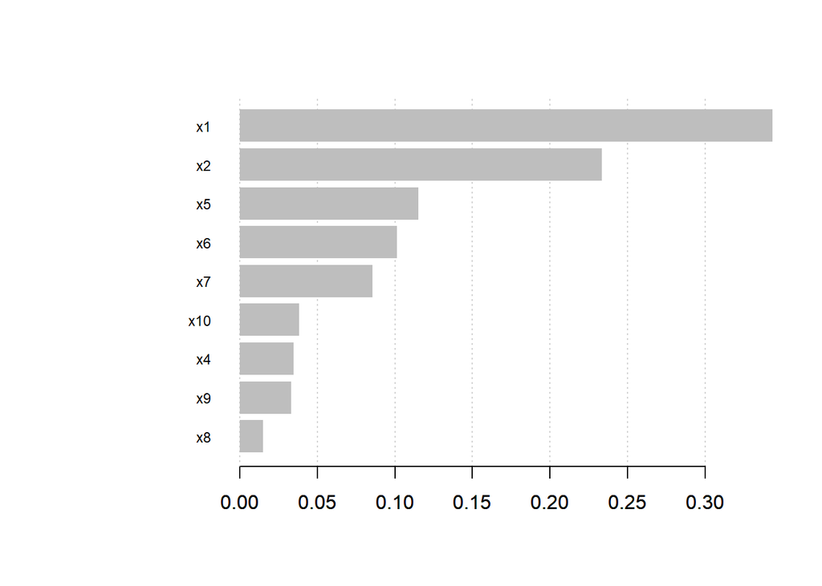

```r
xgb.importance(model = new_data_xgb) %>%
  xgb.plot.importance(top_n = 11)
```

### 第二次

```r
set.seed(17423)
x <- rmvnorm(n = 100,mean = c(0,0,0,0,0,0,0,0,0,0),sigma = diag(1,10))
set.seed(5997)
x_11 <- rnorm(n = 100)
set.seed(515)
sd <- rnorm(100,sd = 4)
y <- 10*x[,1]+5*x[,2]-3*x[,3]+4*x[,4]+8*x[,5]-7*x[,6]+9*x[,7]-2*x[,8]+5*x[,9]-4*x[,10]+10*x[,1]*x[,2]-7*x[,3]*x[,4]+sd
sim <- data.frame(y,x,x_11)


set.seed(12632)
x <- rmvnorm(n = 100,mean = c(0,0,0,0,0,0,0,0,0,0),sigma = diag(1,10))
set.seed(5998)
x_11 <- rnorm(n = 100)
set.seed(597)
sd <- rnorm(100,sd = 4)
y <- 10*x[,1]+5*x[,2]-3*x[,3]+4*x[,4]+8*x[,5]-7*x[,6]+9*x[,7]-2*x[,8]+5*x[,9]-4*x[,10]+10*x[,1]*x[,2]-7*x[,3]*x[,4]+sd
sim_2 <- data.frame(y,x,x_11)


set.seed(18332)
x <- rmvnorm(n = 100,mean = c(0,0,0,0,0,0,0,0,0,0),sigma = diag(1,10))
set.seed(56499)
x_11 <- rnorm(n = 100)
set.seed(517)
sd <- rnorm(100,sd = 4)
y <- 10*x[,1]+5*x[,2]-3*x[,3]+4*x[,4]+8*x[,5]-7*x[,6]+9*x[,7]-2*x[,8]+5*x[,9]-4*x[,10]+10*x[,1]*x[,2]-7*x[,3]*x[,4]+sd
sim_3 <- data.frame(y,x,x_11)





names(sim) <- c("y",paste0("x",1:11))
names(sim_2) <- c("y",paste0("x",1:11))
names(sim_3) <- c("y",paste0("x",1:11))
```

#### use p-value to Variable Selection

```r
(old_data_lm <- lm(y~.,data = sim)) %>% summary()
```

```
##
## Call:
## lm(formula = y ~ ., data = sim)
##
## Residuals:
##     Min      1Q  Median      3Q     Max
## -31.793  -6.699   0.657   7.251  31.577
##
## Coefficients:
##             Estimate Std. Error t value Pr(>|t|)
## (Intercept) -0.03982    1.19740  -0.033 0.973544
## x1          12.65244    1.23047  10.283  < 2e-16 ***
## x2           5.23798    1.31722   3.977 0.000143 ***
## x3          -1.00115    1.21417  -0.825 0.411850
## x4           3.85441    1.18114   3.263 0.001569 **
## x5           6.51410    1.18568   5.494 3.77e-07 ***
## x6          -6.38884    1.25062  -5.109 1.87e-06 ***
## x7           8.29886    1.11098   7.470 5.53e-11 ***
## x8          -1.49485    1.47619  -1.013 0.314007
## x9           6.46332    1.23796   5.221 1.18e-06 ***
## x10         -3.49388    1.22926  -2.842 0.005567 **
## x11          1.07735    1.08873   0.990 0.325111
## ---
## Signif. codes:  0 '***' 0.001 '**' 0.01 '*' 0.05 '.' 0.1 ' ' 1
##
## Residual standard error: 11.63 on 88 degrees of freedom
## Multiple R-squared:  0.7793, Adjusted R-squared:  0.7517
## F-statistic: 28.24 on 11 and 88 DF,  p-value: < 2.2e-16
```

```r
old_data_lm %>% ols_step_forward_p()
```

```
##
##                              Selection Summary
## ---------------------------------------------------------------------------
##         Variable                  Adj.
## Step    Entered     R-Square    R-Square      C(p)        AIC        RMSE
## ---------------------------------------------------------------------------
##    1    x1            0.3338      0.3270    169.6107    878.2052    19.1478
##    2    x7            0.4503      0.4390    125.1517    860.9785    17.4822
##    3    x5            0.5784      0.5652     76.0930    836.4538    15.3904
##    4    x6            0.6299      0.6143     57.5638    825.4281    14.4957
##    5    x9            0.7016      0.6857     30.9825    805.8997    13.0854
##    6    x2            0.7336      0.7165     20.1911    796.5260    12.4283
##    7    x4            0.7544      0.7357     13.9172    790.4142    11.9990
##    8    x10           0.7740      0.7541      8.1167    784.1126    11.5742
## ---------------------------------------------------------------------------
```

```r
(old_data_lm %<>% ols_step_forward_aic())
```

```
##
##                           Selection Summary
## ----------------------------------------------------------------------
## Variable       AIC       Sum Sq         RSS        R-Sq      Adj. R-Sq
## ----------------------------------------------------------------------
## x1           878.205    17999.660    35930.623    0.33376      0.32696
## x7           860.978    24284.427    29645.856    0.45029      0.43896
## x5           836.454    31191.417    22738.866    0.57837      0.56519
## x6           825.428    33968.509    19961.774    0.62986      0.61427
## x9           805.900    37834.866    16095.417    0.70155      0.68568
## x2           796.526    39565.234    14365.049    0.73364      0.71645
## x4           790.414    40684.488    13245.795    0.75439      0.73570
## x10          784.113    41739.703    12190.580    0.77396      0.75408
## ----------------------------------------------------------------------
```

```r
md <- formula(y~x1+x2+x4+x5+x6+x7+x9+x10)
VS <- c(1,2,4,5,6,7,9,10)+1
```

##### old data

###### regression

```r
old_data_lm$model %>% summary()
```

```
##
## Call:
## lm(formula = paste(response, "~", paste(preds, collapse = " + ")),
##     data = l)
##
## Residuals:
##     Min      1Q  Median      3Q     Max
## -35.524  -7.171   0.463   8.339  31.349
##
## Coefficients:
##             Estimate Std. Error t value Pr(>|t|)
## (Intercept)  -0.2577     1.1766  -0.219 0.827132
## x1           12.6142     1.2194  10.345  < 2e-16 ***
## x7            8.4138     1.0973   7.667 1.86e-11 ***
## x5            6.5554     1.1718   5.595 2.31e-07 ***
## x6           -6.3724     1.2415  -5.133 1.61e-06 ***
## x9            6.8011     1.2093   5.624 2.03e-07 ***
## x2            5.0421     1.2762   3.951 0.000153 ***
## x4            3.5658     1.1580   3.079 0.002744 **
## x10          -3.4160     1.2171  -2.807 0.006124 **
## ---
## Signif. codes:  0 '***' 0.001 '**' 0.01 '*' 0.05 '.' 0.1 ' ' 1
##
## Residual standard error: 11.57 on 91 degrees of freedom
## Multiple R-squared:  0.774,  Adjusted R-squared:  0.7541
## F-statistic: 38.95 on 8 and 91 DF,  p-value: < 2.2e-16
```

```r
print("train MSE")
```

```
## [1] "train MSE"
```

```r
label  <- old_data_lm$model %>% predict(sim)
mean((sim$y-label)^2)
```

```
## [1] 121.9058
```

```r
print("test MSE")
```

```
## [1] "test MSE"
```

```r
label  <- old_data_lm$model %>% predict(sim_3)
mean((sim_3$y-label)^2)
```

```
## [1] 210.349
```

###### XGboost

```r
old_data_xgb <- xgboost(data = data.matrix(sim[,VS]),
label = sim[,"y"],
# eta = 0.5,
# max_depth = 10,
nround=25,
# subsample = 0.7,
# colsample_bytree = 0.7,
objective = "reg:squarederror",
verbose = 0
)
print("train MSE")
```

```
## [1] "train MSE"
```

```r
label  <- predict(old_data_xgb,xgb.DMatrix(data.matrix(sim[,VS])))
mean((sim$y-label)^2)
```

```
## [1] 0.0619007
```

```r
print("test MSE")
```

```
## [1] "test MSE"
```

```r
label  <- predict(old_data_xgb,xgb.DMatrix(data.matrix(sim_3[,VS])))
mean((sim_3$y-label)^2)
```

```
## [1] 284.8247
```

```r
xgb.importance(model = old_data_xgb)
```

| Feature | Gain | Cover | Frequency |
| --- | --- | --- | --- |
| x1 | 0.39910017 | 0.33830349 | 0.26812816 |
| x7 | 0.22831062 | 0.13911679 | 0.11973019 |
| x2 | 0.09176303 | 0.10408789 | 0.15514334 |
| x6 | 0.08395557 | 0.08439752 | 0.08600337 |
| x5 | 0.06474922 | 0.10715560 | 0.10792580 |
| x4 | 0.05947817 | 0.08418349 | 0.10623946 |
| x10 | 0.04910519 | 0.07826211 | 0.09106239 |
| x9 | 0.02353803 | 0.06449312 | 0.06576728 |

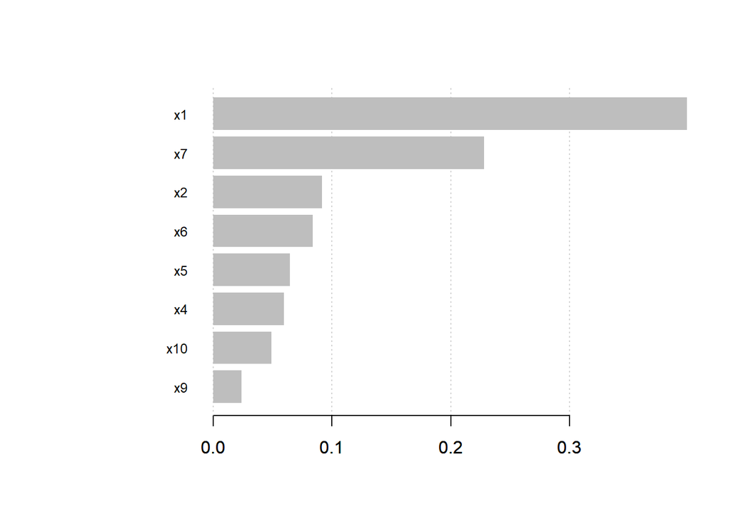

```r
xgb.importance(model = old_data_xgb) %>%
  xgb.plot.importance(top_n = 11)
```

##### new data

###### regression

```r
new_data_lm <- lm(md,data = sim_2)



new_data_lm %>% summary()
```

```
##
## Call:
## lm(formula = md, data = sim_2)
##
## Residuals:
##     Min      1Q  Median      3Q     Max
## -35.843  -7.269   0.131   7.939  30.860
##
## Coefficients:
##             Estimate Std. Error t value Pr(>|t|)
## (Intercept)   0.5373     1.4326   0.375 0.708513
## x1            9.4003     1.3447   6.990 4.44e-10 ***
## x2            5.9590     1.4757   4.038 0.000112 ***
## x4            7.0212     1.4280   4.917 3.88e-06 ***
## x5            4.6080     1.4718   3.131 0.002344 **
## x6           -7.6940     1.3956  -5.513 3.27e-07 ***
## x7            7.4268     1.4738   5.039 2.36e-06 ***
## x9            7.6092     1.4567   5.224 1.10e-06 ***
## x10          -5.1254     1.4718  -3.482 0.000766 ***
## ---
## Signif. codes:  0 '***' 0.001 '**' 0.01 '*' 0.05 '.' 0.1 ' ' 1
##
## Residual standard error: 13.7 on 91 degrees of freedom
## Multiple R-squared:  0.641,  Adjusted R-squared:  0.6094
## F-statistic: 20.31 on 8 and 91 DF,  p-value: < 2.2e-16
```

```r
print("train MSE")
```

```
## [1] "train MSE"
```

```r
label  <- new_data_lm %>% predict(sim_2)
mean((sim_2$y-label)^2)
```

```
## [1] 170.8588
```

```r
print("test MSE")
```

```
## [1] "test MSE"
```

```r
label  <- new_data_lm %>% predict(sim_3)
mean((sim_3$y-label)^2)
```

```
## [1] 216.6385
```

###### XGboost

```r
new_data_xgb <- xgboost(data = data.matrix(sim_2[,VS]),
label = sim_2[,"y"],
# eta = 0.5,
# max_depth = 10,
nround=25,
# subsample = 0.7,
# colsample_bytree = 0.7,
objective = "reg:squarederror",
verbose = 0
)
print("train MSE")
```

```
## [1] "train MSE"
```

```r
label  <- predict(new_data_xgb,xgb.DMatrix(data.matrix(sim_2[,VS])))
mean((sim_2$y-label)^2)
```

```
## [1] 0.3268886
```

```r
print("test MSE")
```

```
## [1] "test MSE"
```

```r
label  <- predict(new_data_xgb,xgb.DMatrix(data.matrix(sim_3[,VS])))
mean((sim_3$y-label)^2)
```

```
## [1] 331.3769
```

```r
xgb.importance(model = new_data_xgb)
```

| Feature | Gain | Cover | Frequency |
| --- | --- | --- | --- |
| x2 | 0.20961396 | 0.23481414 | 0.17180617 |
| x1 | 0.17712978 | 0.19038985 | 0.25991189 |
| x6 | 0.13543199 | 0.06960039 | 0.09471366 |
| x7 | 0.12998435 | 0.15914638 | 0.10792952 |
| x9 | 0.12768207 | 0.10816654 | 0.08590308 |
| x5 | 0.09974932 | 0.05628008 | 0.08149780 |
| x10 | 0.07800119 | 0.10628356 | 0.09471366 |
| x4 | 0.04240733 | 0.07531906 | 0.10352423 |

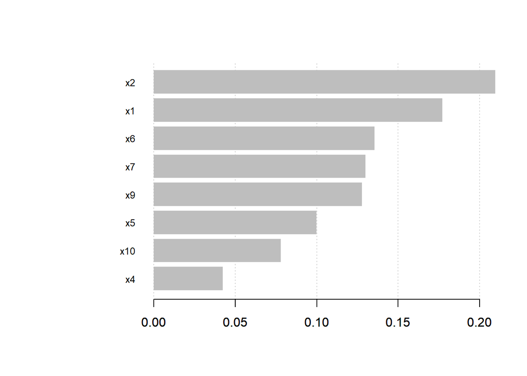

```r
xgb.importance(model = new_data_xgb) %>%
  xgb.plot.importance(top_n = 11)
```

#### use Gain to Variable Selection

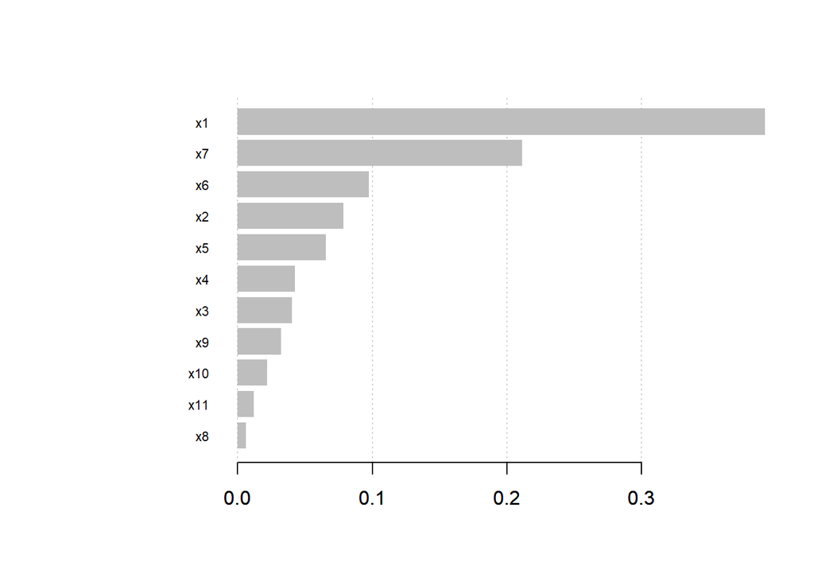

```r
xgb_test <- xgboost(data = data.matrix(sim[,-1]),
label = sim[,"y"],
# eta = 0.5,
# max_depth = 10,
nround=25,
# subsample = 0.7,
# colsample_bytree = 0.7,
objective = "reg:squarederror",
verbose = 0
)

xgb.importance(model = xgb_test) %>%
  xgb.plot.importance(top_n = 11)
```

```r
md <- formula(y~x1+x2+x3+x4+x5+x6+x7+x9)
VS <- c(1,2,3,4,5,6,7,9)+1
```

##### old data

###### regression

```r
old_data_lm <- lm(md,data = sim)



old_data_lm %>% summary()
```

```
##
## Call:
## lm(formula = md, data = sim)
##
## Residuals:
##     Min      1Q  Median      3Q     Max
## -35.130  -6.835   0.317   7.650  31.510
##
## Coefficients:
##             Estimate Std. Error t value Pr(>|t|)
## (Intercept) -0.02294    1.23581  -0.019 0.985230
## x1          12.61142    1.27361   9.902 4.09e-16 ***
## x2           4.84556    1.32792   3.649 0.000439 ***
## x3          -0.25437    1.21028  -0.210 0.834003
## x4           3.34566    1.20428   2.778 0.006640 **
## x5           5.89620    1.20109   4.909 4.00e-06 ***
## x6          -6.73127    1.28712  -5.230 1.08e-06 ***
## x7           8.82457    1.13427   7.780 1.09e-11 ***
## x9           6.67651    1.26588   5.274 8.95e-07 ***
## ---
## Signif. codes:  0 '***' 0.001 '**' 0.01 '*' 0.05 '.' 0.1 ' ' 1
##
## Residual standard error: 12.06 on 91 degrees of freedom
## Multiple R-squared:  0.7545, Adjusted R-squared:  0.7329
## F-statistic: 34.96 on 8 and 91 DF,  p-value: < 2.2e-16
```

```r
print("train MSE")
```

```
## [1] "train MSE"
```

```r
label  <- old_data_lm %>% predict(sim)
mean((sim$y-label)^2)
```

```
## [1] 132.3937
```

```r
print("test MSE")
```

```
## [1] "test MSE"
```

```r
label  <- old_data_lm %>% predict(sim_3)
mean((sim_3$y-label)^2)
```

```
## [1] 223.1532
```

###### XGboost

```r
old_data_xgb <- xgboost(data = data.matrix(sim[,VS]),
label = sim[,"y"],
# eta = 0.5,
# max_depth = 10,
nround=25,
# subsample = 0.7,
# colsample_bytree = 0.7,
objective = "reg:squarederror",
verbose = 0
)
print("train MSE")
```

```
## [1] "train MSE"
```

```r
label  <- predict(old_data_xgb,xgb.DMatrix(data.matrix(sim[,VS])))
mean((sim$y-label)^2)
```

```
## [1] 0.06084383
```

```r
print("test MSE")
```

```
## [1] "test MSE"
```

```r
label  <- predict(old_data_xgb,xgb.DMatrix(data.matrix(sim_3[,VS])))
mean((sim_3$y-label)^2)
```

```
## [1] 260.4621
```

```r
xgb.importance(model = old_data_xgb)
```

| Feature | Gain | Cover | Frequency |
| --- | --- | --- | --- |
| x1 | 0.39527847 | 0.30961745 | 0.26288660 |
| x7 | 0.22063908 | 0.15423668 | 0.12371134 |
| x6 | 0.10032465 | 0.11133357 | 0.09793814 |
| x2 | 0.08567337 | 0.10718627 | 0.14089347 |
| x5 | 0.06225915 | 0.09781909 | 0.10137457 |
| x4 | 0.05356415 | 0.10003575 | 0.11168385 |
| x3 | 0.04396318 | 0.05341437 | 0.08247423 |
| x9 | 0.03829795 | 0.06635681 | 0.07903780 |

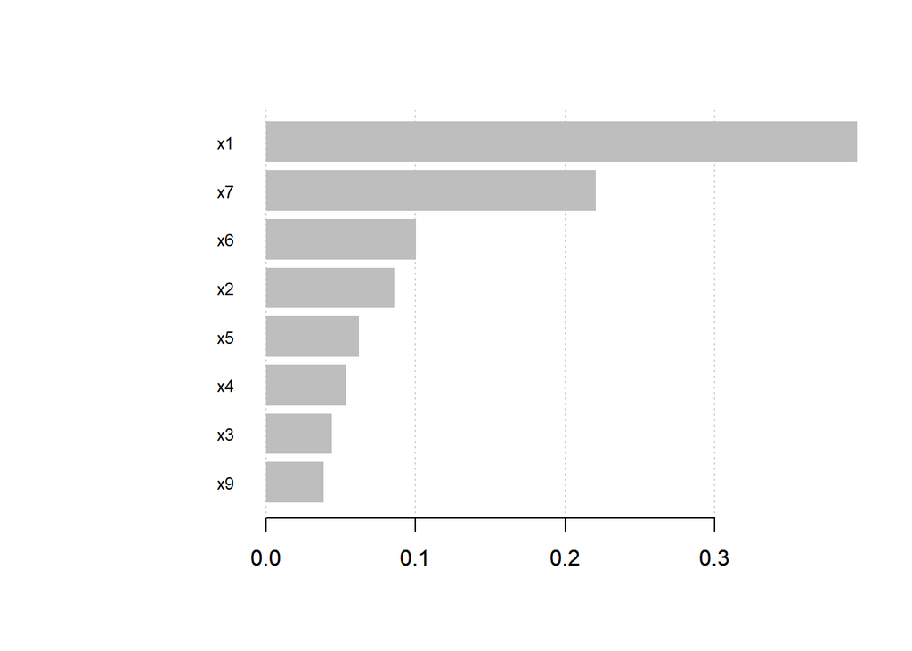

```r
xgb.importance(model = old_data_xgb) %>%
  xgb.plot.importance(top_n = 11)
```

##### new data

###### regression

```r
new_data_lm <- lm(md,data = sim_2)



new_data_lm %>% summary()
```

```
##
## Call:
## lm(formula = md, data = sim_2)
##
## Residuals:
##     Min      1Q  Median      3Q     Max
## -30.541  -7.979   0.101   8.344  35.386
##
## Coefficients:
##             Estimate Std. Error t value Pr(>|t|)
## (Intercept)   0.8607     1.4235   0.605 0.546903
## x1            8.6550     1.3335   6.490 4.41e-09 ***
## x2            6.7134     1.4766   4.546 1.68e-05 ***
## x3           -4.9250     1.3110  -3.757 0.000303 ***
## x4            7.3644     1.4070   5.234 1.06e-06 ***
## x5            4.0919     1.4607   2.801 0.006218 **
## x6           -7.2401     1.3827  -5.236 1.05e-06 ***
## x7            8.6231     1.5237   5.659 1.75e-07 ***
## x9            7.5577     1.4433   5.236 1.05e-06 ***
## ---
## Signif. codes:  0 '***' 0.001 '**' 0.01 '*' 0.05 '.' 0.1 ' ' 1
##
## Residual standard error: 13.57 on 91 degrees of freedom
## Multiple R-squared:  0.6478, Adjusted R-squared:  0.6168
## F-statistic: 20.92 on 8 and 91 DF,  p-value: < 2.2e-16
```

```r
print("train MSE")
```

```
## [1] "train MSE"
```

```r
label  <- new_data_lm %>% predict(sim_2)
mean((sim_2$y-label)^2)
```

```
## [1] 167.631
```

```r
print("test MSE")
```

```
## [1] "test MSE"
```

```r
label  <- new_data_lm %>% predict(sim_3)
mean((sim_3$y-label)^2)
```

```
## [1] 240.3119
```

###### XGboost

```r
new_data_xgb <- xgboost(data = data.matrix(sim_2[,VS]),
label = sim_2[,"y"],
# eta = 0.5,
# max_depth = 10,
nround=25,
# subsample = 0.7,
# colsample_bytree = 0.7,
objective = "reg:squarederror",
verbose = 0
)
print("train MSE")
```

```
## [1] "train MSE"
```

```r
label  <- predict(new_data_xgb,xgb.DMatrix(data.matrix(sim_2[,VS])))
mean((sim_2$y-label)^2)
```

```
## [1] 0.255596
```

```r
print("test MSE")
```

```
## [1] "test MSE"
```

```r
label  <- predict(new_data_xgb,xgb.DMatrix(data.matrix(sim_3[,VS])))
mean((sim_3$y-label)^2)
```

```
## [1] 327.9329
```

```r
xgb.importance(model = new_data_xgb)
```

| Feature | Gain | Cover | Frequency |
| --- | --- | --- | --- |
| x2 | 0.18839263 | 0.23581548 | 0.20042644 |
| x1 | 0.16552417 | 0.17098192 | 0.24520256 |
| x7 | 0.14089476 | 0.20762091 | 0.10874200 |
| x6 | 0.13517235 | 0.09372601 | 0.07675906 |
| x9 | 0.12834737 | 0.07676739 | 0.07462687 |
| x3 | 0.10855678 | 0.07523205 | 0.11300640 |
| x4 | 0.06944278 | 0.07181241 | 0.10660981 |
| x5 | 0.06366916 | 0.06804383 | 0.07462687 |

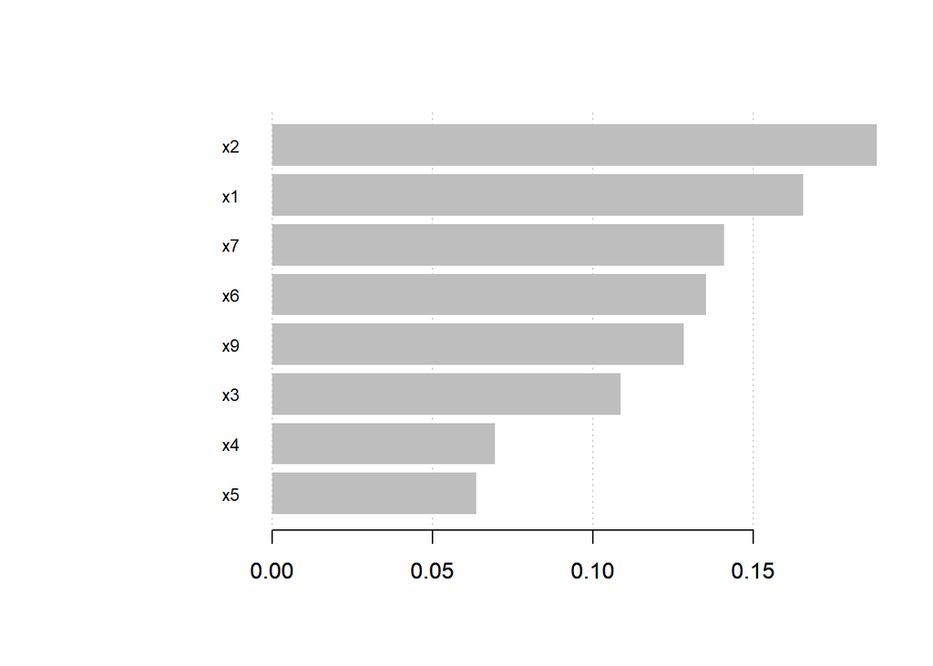

```r
xgb.importance(model = new_data_xgb) %>%
  xgb.plot.importance(top_n = 11)
```

### 第三次

```r
set.seed(1443)
x <- rmvnorm(n = 100,mean = c(0,0,0,0,0,0,0,0,0,0),sigma = diag(1,10))
set.seed(5697)
x_11 <- rnorm(n = 100)
set.seed(1005)
sd <- rnorm(100,sd = 4)
y <- 10*x[,1]+5*x[,2]-3*x[,3]+4*x[,4]+8*x[,5]-7*x[,6]+9*x[,7]-2*x[,8]+5*x[,9]-4*x[,10]+10*x[,1]*x[,2]-7*x[,3]*x[,4]+sd
sim <- data.frame(y,x,x_11)


set.seed(13232)
x <- rmvnorm(n = 100,mean = c(0,0,0,0,0,0,0,0,0,0),sigma = diag(1,10))
set.seed(1009)
x_11 <- rnorm(n = 100)
set.seed(547)
sd <- rnorm(100,sd = 4)
y <- 10*x[,1]+5*x[,2]-3*x[,3]+4*x[,4]+8*x[,5]-7*x[,6]+9*x[,7]-2*x[,8]+5*x[,9]-4*x[,10]+10*x[,1]*x[,2]-7*x[,3]*x[,4]+sd
sim_2 <- data.frame(y,x,x_11)


set.seed(1232)
x <- rmvnorm(n = 100,mean = c(0,0,0,0,0,0,0,0,0,0),sigma = diag(1,10))
set.seed(5659)
x_11 <- rnorm(n = 100)
set.seed(5867)
sd <- rnorm(100,sd = 4)
y <- 10*x[,1]+5*x[,2]-3*x[,3]+4*x[,4]+8*x[,5]-7*x[,6]+9*x[,7]-2*x[,8]+5*x[,9]-4*x[,10]+10*x[,1]*x[,2]-7*x[,3]*x[,4]+sd
sim_3 <- data.frame(y,x,x_11)





names(sim) <- c("y",paste0("x",1:11))
names(sim_2) <- c("y",paste0("x",1:11))
names(sim_3) <- c("y",paste0("x",1:11))
```

#### use p-value to Variable Selection

```r
(old_data_lm <- lm(y~.,data = sim)) %>% summary()
```

```
##
## Call:
## lm(formula = y ~ ., data = sim)
##
## Residuals:
##     Min      1Q  Median      3Q     Max
## -27.526  -7.933  -0.826   7.220  42.365
##
## Coefficients:
##             Estimate Std. Error t value Pr(>|t|)
## (Intercept)  -0.2623     1.2575  -0.209 0.835229
## x1           10.2586     1.2759   8.040 3.84e-12 ***
## x2            5.1631     1.3682   3.774 0.000291 ***
## x3           -3.3059     1.2179  -2.715 0.007987 **
## x4            4.4935     1.2296   3.654 0.000438 ***
## x5            7.9976     1.3083   6.113 2.62e-08 ***
## x6           -3.4818     1.2910  -2.697 0.008386 **
## x7           10.9432     1.1951   9.157 1.95e-14 ***
## x8           -2.7483     1.1469  -2.396 0.018682 *
## x9            5.2340     1.2439   4.208 6.20e-05 ***
## x10          -5.5472     1.2580  -4.409 2.92e-05 ***
## x11           0.8919     1.4928   0.598 0.551696
## ---
## Signif. codes:  0 '***' 0.001 '**' 0.01 '*' 0.05 '.' 0.1 ' ' 1
##
## Residual standard error: 12.14 on 88 degrees of freedom
## Multiple R-squared:  0.7381, Adjusted R-squared:  0.7054
## F-statistic: 22.55 on 11 and 88 DF,  p-value: < 2.2e-16
```

```r
old_data_lm %>% ols_step_forward_p()
```

```
##
##                              Selection Summary
## ---------------------------------------------------------------------------
##         Variable                  Adj.
## Step    Entered     R-Square    R-Square      C(p)        AIC        RMSE
## ---------------------------------------------------------------------------
##    1    x7            0.2574      0.2498    153.5596    880.5866    19.3772
##    2    x1            0.4155      0.4034    102.4333    858.6491    17.2798
##    3    x5            0.5224      0.5074     68.5079    840.4511    15.7011
##    4    x9            0.5763      0.5585     52.3803    830.4670    14.8655
##    5    x10           0.6196      0.5994     39.8261    821.6839    14.1600
##    6    x2            0.6461      0.6233     32.9177    816.4600    13.7309
##    7    x4            0.6764      0.6518     24.7541    809.5258    13.2022
##    8    x3            0.7017      0.6755     18.2397    803.3733    12.7443
##    9    x6            0.7208      0.6929     13.8269    798.7619    12.3982
##   10    x8            0.7371      0.7075     10.3570    794.7554    12.0988
## ---------------------------------------------------------------------------
```

```r
(old_data_lm %<>% ols_step_forward_aic())
```

```
##
##                           Selection Summary
## ----------------------------------------------------------------------
## Variable       AIC       Sum Sq         RSS        R-Sq      Adj. R-Sq
## ----------------------------------------------------------------------
## x7           880.587    12752.463    36796.536    0.25737      0.24979
## x1           858.649    20585.718    28963.281    0.41546      0.40341
## x5           840.451    25882.764    23666.235    0.52237      0.50744
## x9           830.467    28555.608    20993.391    0.57631      0.55847
## x10          821.684    30701.559    18847.440    0.61962      0.59939
## x2           816.460    32015.073    17533.925    0.64613      0.62330
## x4           809.526    33513.648    16035.350    0.67637      0.65175
## x3           803.373    34769.064    14779.935    0.70171      0.67549
## x6           798.762    35714.613    13834.385    0.72079      0.69287
## x8           794.755    36521.118    13027.880    0.73707      0.70753
## ----------------------------------------------------------------------
```

```r
md <- formula(y~.-x11)
VS <- 1:10+1
```

##### old data

###### regression

```r
old_data_lm$model %>% summary()
```

```
##
## Call:
## lm(formula = paste(response, "~", paste(preds, collapse = " + ")),
##     data = l)
##
## Residuals:
##     Min      1Q  Median      3Q     Max
## -27.769  -7.337  -0.656   6.781  41.669
##
## Coefficients:
##             Estimate Std. Error t value Pr(>|t|)
## (Intercept)  -0.3113     1.2503  -0.249 0.803984
## x7           10.8564     1.1820   9.185 1.56e-14 ***
## x1           10.2773     1.2709   8.087 2.89e-12 ***
## x5            8.0945     1.2935   6.258 1.34e-08 ***
## x9            5.2631     1.2385   4.250 5.26e-05 ***
## x10          -5.6166     1.2481  -4.500 2.05e-05 ***
## x2            5.0011     1.3362   3.743 0.000322 ***
## x4            4.4174     1.2185   3.625 0.000481 ***
## x3           -3.4104     1.2009  -2.840 0.005591 **
## x6           -3.3886     1.2769  -2.654 0.009429 **
## x8           -2.6601     1.1333  -2.347 0.021130 *
## ---
## Signif. codes:  0 '***' 0.001 '**' 0.01 '*' 0.05 '.' 0.1 ' ' 1
##
## Residual standard error: 12.1 on 89 degrees of freedom
## Multiple R-squared:  0.7371, Adjusted R-squared:  0.7075
## F-statistic: 24.95 on 10 and 89 DF,  p-value: < 2.2e-16
```

```r
print("train MSE")
```

```
## [1] "train MSE"
```

```r
label  <- old_data_lm$model %>% predict(sim)
mean((sim$y-label)^2)
```

```
## [1] 130.2788
```

```r
print("test MSE")
```

```
## [1] "test MSE"
```

```r
label  <- old_data_lm$model %>% predict(sim_3)
mean((sim_3$y-label)^2)
```

```
## [1] 167.5278
```

###### XGboost

```r
old_data_xgb <- xgboost(data = data.matrix(sim[,VS]),
label = sim[,"y"],
# eta = 0.5,
# max_depth = 10,
nround=25,
# subsample = 0.7,
# colsample_bytree = 0.7,
objective = "reg:squarederror",
verbose = 0
)
print("train MSE")
```

```
## [1] "train MSE"
```

```r
label  <- predict(old_data_xgb,xgb.DMatrix(data.matrix(sim[,VS])))
mean((sim$y-label)^2)
```

```
## [1] 0.1189729
```

```r
print("test MSE")
```

```
## [1] "test MSE"
```

```r
label  <- predict(old_data_xgb,xgb.DMatrix(data.matrix(sim_3[,VS])))
mean((sim_3$y-label)^2)
```

```
## [1] 311.9262
```

```r
xgb.importance(model = old_data_xgb)
```

| Feature | Gain | Cover | Frequency |
| --- | --- | --- | --- |
| x7 | 0.31235240 | 0.14356505 | 0.10229645 |
| x1 | 0.18273691 | 0.23443607 | 0.24217119 |
| x5 | 0.17591772 | 0.11522892 | 0.09812109 |
| x2 | 0.14605461 | 0.17462312 | 0.14196242 |
| x10 | 0.05995345 | 0.07537688 | 0.06263048 |
| x8 | 0.03147873 | 0.05778894 | 0.05636743 |
| x9 | 0.03034629 | 0.04752931 | 0.05219207 |
| x6 | 0.02649744 | 0.06881630 | 0.08768267 |
| x3 | 0.01950694 | 0.05039084 | 0.08768267 |
| x4 | 0.01515550 | 0.03224456 | 0.06889353 |

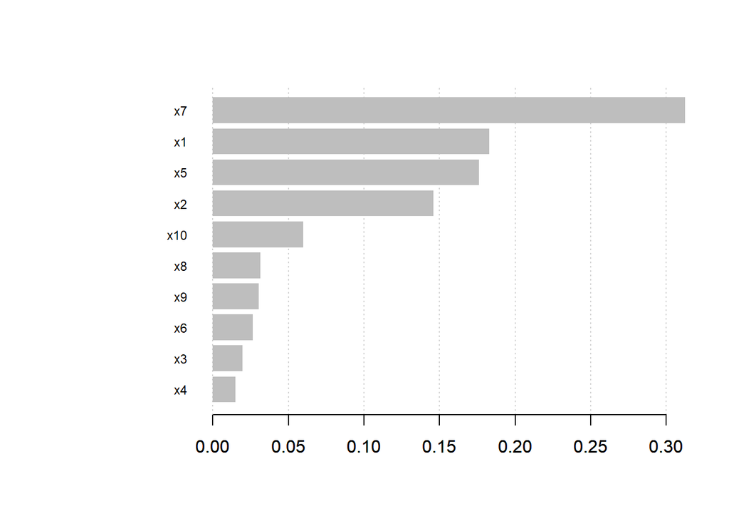

```r
xgb.importance(model = old_data_xgb) %>%
  xgb.plot.importance(top_n = 11)
```

##### new data

###### regression

```r
new_data_lm <- lm(md,data = sim_2)



new_data_lm %>% summary()
```

```
##
## Call:
## lm(formula = md, data = sim_2)
##
## Residuals:
##     Min      1Q  Median      3Q     Max
## -35.237  -6.823  -0.519   7.524  49.054
##
## Coefficients:
##             Estimate Std. Error t value Pr(>|t|)
## (Intercept)    0.168      1.364   0.123  0.90227
## x1             9.206      1.205   7.641 2.36e-11 ***
## x2             8.678      1.513   5.735 1.32e-07 ***
## x3            -4.091      1.503  -2.721  0.00783 **
## x4             4.266      1.260   3.385  0.00106 **
## x5            10.007      1.306   7.661 2.14e-11 ***
## x6            -9.148      1.445  -6.332 9.59e-09 ***
## x7             7.971      1.274   6.257 1.34e-08 ***
## x8            -2.920      1.415  -2.063  0.04204 *
## x9             3.593      1.354   2.653  0.00944 **
## x10           -3.570      1.333  -2.678  0.00882 **
## ---
## Signif. codes:  0 '***' 0.001 '**' 0.01 '*' 0.05 '.' 0.1 ' ' 1
##
## Residual standard error: 13.21 on 89 degrees of freedom
## Multiple R-squared:  0.7709, Adjusted R-squared:  0.7451
## F-statistic: 29.95 on 10 and 89 DF,  p-value: < 2.2e-16
```

```r
print("train MSE")
```

```
## [1] "train MSE"
```

```r
label  <- new_data_lm %>% predict(sim_2)
mean((sim_2$y-label)^2)
```

```
## [1] 155.2747
```

```r
print("test MSE")
```

```
## [1] "test MSE"
```

```r
label  <- new_data_lm %>% predict(sim_3)
mean((sim_3$y-label)^2)
```

```
## [1] 172.8843
```

###### XGboost

```r
new_data_xgb <- xgboost(data = data.matrix(sim_2[,VS]),
label = sim_2[,"y"],
# eta = 0.5,
# max_depth = 10,
nround=25,
# subsample = 0.7,
# colsample_bytree = 0.7,
objective = "reg:squarederror",
verbose = 0
)
print("train MSE")
```

```
## [1] "train MSE"
```

```r
label  <- predict(new_data_xgb,xgb.DMatrix(data.matrix(sim_2[,VS])))
mean((sim_2$y-label)^2)
```

```
## [1] 0.1430329
```

```r
print("test MSE")
```

```
## [1] "test MSE"
```

```r
label  <- predict(new_data_xgb,xgb.DMatrix(data.matrix(sim_3[,VS])))
mean((sim_3$y-label)^2)
```

```
## [1] 362.3607
```

```r
xgb.importance(model = new_data_xgb)
```

| Feature | Gain | Cover | Frequency |
| --- | --- | --- | --- |
| x6 | 0.25464881 | 0.11720930 | 0.06439394 |
| x5 | 0.22103693 | 0.11677996 | 0.08143939 |
| x1 | 0.17173840 | 0.23270125 | 0.29356061 |
| x4 | 0.09349937 | 0.09288014 | 0.10606061 |
| x7 | 0.08914135 | 0.09431127 | 0.07954545 |
| x2 | 0.06641780 | 0.10490161 | 0.10795455 |
| x3 | 0.03317950 | 0.10339893 | 0.10984848 |
| x9 | 0.03291427 | 0.05216458 | 0.05303030 |
| x10 | 0.02319984 | 0.04973166 | 0.04734848 |
| x8 | 0.01422372 | 0.03592129 | 0.05681818 |

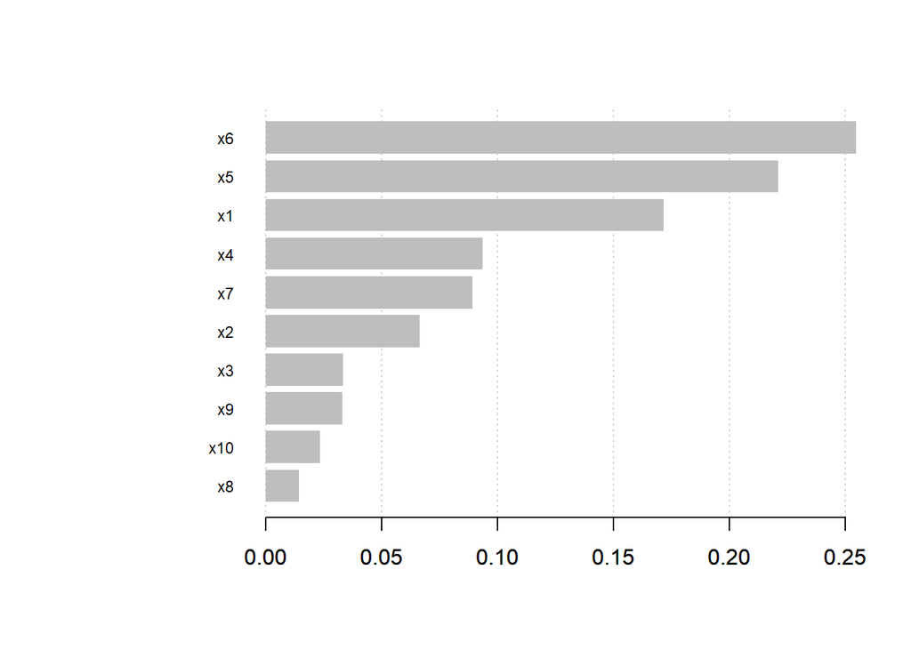

```r
xgb.importance(model = new_data_xgb) %>%
  xgb.plot.importance(top_n = 11)
```

#### use Gain to Variable Selection

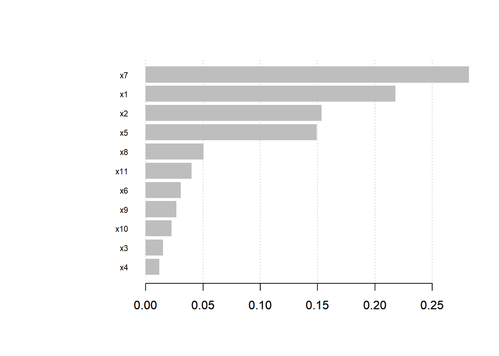

```r
xgb_test <- xgboost(data = data.matrix(sim[,-1]),
label = sim[,"y"],
# eta = 0.5,
# max_depth = 10,
nround=25,
# subsample = 0.7,
# colsample_bytree = 0.7,
objective = "reg:squarederror",
verbose = 0
)

xgb.importance(model = xgb_test) %>%
  xgb.plot.importance(top_n = 11)
```

```r
md <- formula(y~.-x4)
VS <- c(1,2,3,5,6,7,8,9,10,11)+1
```

##### old data

###### regression

```r
old_data_lm <- lm(md,data = sim)



old_data_lm %>% summary()
```

```
##
## Call:
## lm(formula = md, data = sim)
##
## Residuals:
##     Min      1Q  Median      3Q     Max
## -26.844  -7.411  -0.055   7.129  44.424
##
## Coefficients:
##             Estimate Std. Error t value Pr(>|t|)
## (Intercept)  -0.6689     1.3367  -0.500 0.618007
## x1           10.1154     1.3610   7.433 6.24e-11 ***
## x2            4.2168     1.4337   2.941 0.004166 **
## x3           -3.2094     1.2993  -2.470 0.015419 *
## x5            8.5251     1.3877   6.143 2.22e-08 ***
## x6           -2.9213     1.3680  -2.136 0.035463 *
## x7           11.0178     1.2752   8.640 2.09e-13 ***
## x8           -2.5861     1.2230  -2.114 0.037270 *
## x9            4.9356     1.3246   3.726 0.000341 ***
## x10          -5.5106     1.3425  -4.105 8.95e-05 ***
## x11           0.3275     1.5844   0.207 0.836738
## ---
## Signif. codes:  0 '***' 0.001 '**' 0.01 '*' 0.05 '.' 0.1 ' ' 1
##
## Residual standard error: 12.96 on 89 degrees of freedom
## Multiple R-squared:  0.6984, Adjusted R-squared:  0.6645
## F-statistic: 20.61 on 10 and 89 DF,  p-value: < 2.2e-16
```

```r
print("train MSE")
```

```
## [1] "train MSE"
```

```r
label  <- old_data_lm %>% predict(sim)
mean((sim$y-label)^2)
```

```
## [1] 149.4441
```

```r
print("test MSE")
```

```
## [1] "test MSE"
```

```r
label  <- old_data_lm %>% predict(sim_3)
mean((sim_3$y-label)^2)
```

```
## [1] 170.3006
```

###### XGboost

```r
old_data_xgb <- xgboost(data = data.matrix(sim[,VS]),
label = sim[,"y"],
# eta = 0.5,
# max_depth = 10,
nround=25,
# subsample = 0.7,
# colsample_bytree = 0.7,
objective = "reg:squarederror",
verbose = 0
)
print("train MSE")
```

```
## [1] "train MSE"
```

```r
label  <- predict(old_data_xgb,xgb.DMatrix(data.matrix(sim[,VS])))
mean((sim$y-label)^2)
```

```
## [1] 0.08734063
```

```r
print("test MSE")
```

```
## [1] "test MSE"
```

```r
label  <- predict(old_data_xgb,xgb.DMatrix(data.matrix(sim_3[,VS])))
mean((sim_3$y-label)^2)
```

```
## [1] 258.2933
```

```r
xgb.importance(model = old_data_xgb)
```

| Feature | Gain | Cover | Frequency |
| --- | --- | --- | --- |
| x7 | 0.28388234 | 0.13594146 | 0.08403361 |
| x1 | 0.22127697 | 0.22051787 | 0.24369748 |
| x2 | 0.15394822 | 0.17963693 | 0.16176471 |
| x5 | 0.15310789 | 0.12996060 | 0.11974790 |
| x8 | 0.04841633 | 0.04643963 | 0.08403361 |
| x11 | 0.04156857 | 0.04228821 | 0.04411765 |
| x6 | 0.03068435 | 0.08338024 | 0.09453782 |
| x9 | 0.02926426 | 0.04862088 | 0.05252101 |
| x10 | 0.02492024 | 0.06121587 | 0.06092437 |
| x3 | 0.01293083 | 0.05199831 | 0.05462185 |

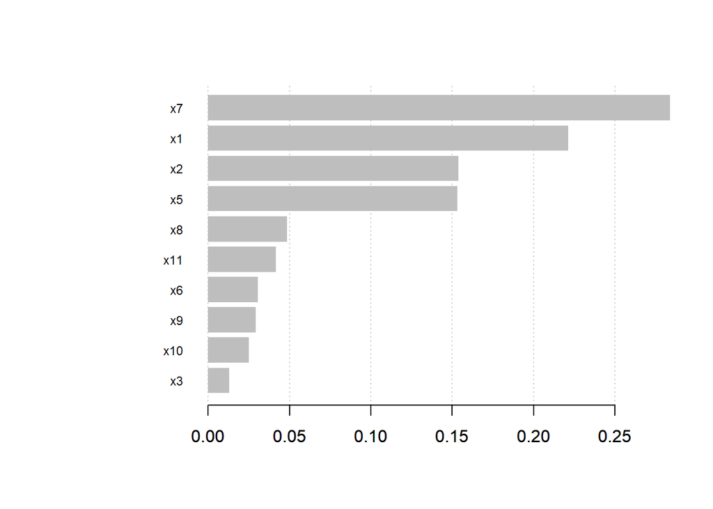

```r
xgb.importance(model = old_data_xgb) %>%
  xgb.plot.importance(top_n = 11)
```

##### new data

###### regression

```r
new_data_lm <- lm(md,data = sim_2)



new_data_lm %>% summary()
```

```
##
## Call:
## lm(formula = md, data = sim_2)
##
## Residuals:
##     Min      1Q  Median      3Q     Max
## -39.606  -8.257   1.595   7.644  41.080
##
## Coefficients:
##             Estimate Std. Error t value Pr(>|t|)
## (Intercept)  0.05714    1.41905   0.040  0.96797
## x1           9.58198    1.27087   7.540 3.78e-11 ***
## x2          10.02851    1.60053   6.266 1.29e-08 ***
## x3          -4.44605    1.55550  -2.858  0.00530 **
## x5          10.68616    1.36033   7.856 8.59e-12 ***
## x6          -9.89964    1.49401  -6.626 2.55e-09 ***
## x7           8.08502    1.32024   6.124 2.42e-08 ***
## x8          -3.46151    1.51115  -2.291  0.02435 *
## x9           4.09610    1.40327   2.919  0.00445 **
## x10         -3.23438    1.38438  -2.336  0.02172 *
## x11         -3.23062    1.53333  -2.107  0.03794 *
## ---
## Signif. codes:  0 '***' 0.001 '**' 0.01 '*' 0.05 '.' 0.1 ' ' 1
##
## Residual standard error: 13.7 on 89 degrees of freedom
## Multiple R-squared:  0.7537, Adjusted R-squared:  0.726
## F-statistic: 27.23 on 10 and 89 DF,  p-value: < 2.2e-16
```

```r
print("train MSE")
```

```
## [1] "train MSE"
```

```r
label  <- new_data_lm %>% predict(sim_2)
mean((sim_2$y-label)^2)
```

```
## [1] 166.9413
```

```r
print("test MSE")
```

```
## [1] "test MSE"
```

```r
label  <- new_data_lm %>% predict(sim_3)
mean((sim_3$y-label)^2)
```

```
## [1] 194.8284
```

###### XGboost

```r
new_data_xgb <- xgboost(data = data.matrix(sim_2[,VS]),
label = sim_2[,"y"],
# eta = 0.5,
# max_depth = 10,
nround=25,
# subsample = 0.7,
# colsample_bytree = 0.7,
objective = "reg:squarederror",
verbose = 0
)
print("train MSE")
```

```
## [1] "train MSE"
```

```r
label  <- predict(new_data_xgb,xgb.DMatrix(data.matrix(sim_2[,VS])))
mean((sim_2$y-label)^2)
```

```
## [1] 0.2348935
```

```r
print("test MSE")
```

```
## [1] "test MSE"
```

```r
label  <- predict(new_data_xgb,xgb.DMatrix(data.matrix(sim_3[,VS])))
mean((sim_3$y-label)^2)
```

```
## [1] 334.5497
```

```r
xgb.importance(model = new_data_xgb)
```

| Feature | Gain | Cover | Frequency |
| --- | --- | --- | --- |
| x6 | 0.25696445 | 0.09426518 | 0.06876228 |
| x5 | 0.21014780 | 0.12702550 | 0.09823183 |
| x1 | 0.17746009 | 0.25207834 | 0.27308448 |
| x2 | 0.10384637 | 0.09285614 | 0.11198428 |
| x7 | 0.10031431 | 0.09243342 | 0.08447937 |
| x9 | 0.05291271 | 0.04417359 | 0.03732809 |
| x10 | 0.03806767 | 0.08869945 | 0.08840864 |
| x3 | 0.03099937 | 0.10293082 | 0.11591356 |
| x8 | 0.01802863 | 0.05199380 | 0.07858546 |
| x11 | 0.01125861 | 0.05354375 | 0.04322200 |

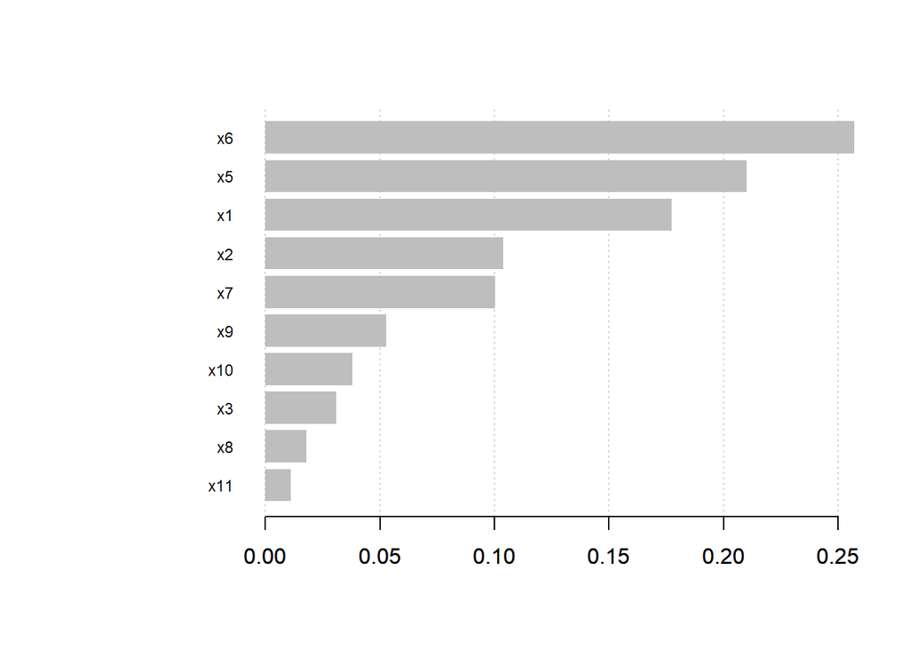

```r
xgb.importance(model = new_data_xgb) %>%
  xgb.plot.importance(top_n = 11)
```

## 資料三(只有交互作用項)

regression的表現又更差了，train和test的MSE差距更大了。  
XGboost還是差不多的狀況。

$x_{1 \sim 10}\sim MN(\mu , \Sigma )$ $\mu=(0,0,0,0,0,0,0,0,0,0)$
$$\Sigma = \begin{pmatrix}
1 & 0 & 0 & 0 & 0 & 0 & 0 & 0 & 0 & 0\\
0 & 1& 0 & 0 & 0 & 0 & 0 & 0 & 0 & 0\\
0 & 0& 1 & 0 & 0 & 0 & 0 & 0 & 0 & 0\\
0 & 0& 0 & 1 & 0 & 0 & 0 & 0 & 0 & 0\\
0 & 0& 0 & 0 & 1 & 0 & 0 & 0 & 0 & 0\\
0 & 0& 0 & 0 & 0 & 1 & 0 & 0 & 0 & 0\\
0 & 0& 0 & 0 & 0 & 0 & 1 & 0 & 0 & 0\\
0 & 0& 0 & 0 & 0 & 0 & 0 & 1 & 0 & 0\\
0 & 0& 0 & 0 & 0 & 0 & 0 & 0 & 1 & 0\\
0 & 0& 0 & 0 & 0 & 0 & 0 & 0 & 0 & 1
\end{pmatrix}$$

$x_{11} \sim N(0,1)$

$y=+10x_1x_2-7x_3x_4-8x_6x_9+\epsilon$

$\epsilon \sim N(0,4)$

### 第一次

```r
set.seed(1423)
x <- rmvnorm(n = 100,mean = c(0,0,0,0,0,0,0,0,0,0),sigma = diag(1,10))
set.seed(597)
x_11 <- rnorm(n = 100)
set.seed(55)
sd <- rnorm(100,sd = 4)
y <- 10*x[,1]*x[,2]-7*x[,3]*x[,4]-8*x[,6]*x[,9]+sd
sim <- data.frame(y,x,x_11)


set.seed(1232)
x <- rmvnorm(n = 100,mean = c(0,0,0,0,0,0,0,0,0,0),sigma = diag(1,10))
set.seed(599)
x_11 <- rnorm(n = 100)
set.seed(57)
sd <- rnorm(100,sd = 4)
y <- 10*x[,1]*x[,2]-7*x[,3]*x[,4]-8*x[,6]*x[,9]+sd
sim_2 <- data.frame(y,x,x_11)

set.seed(1252)
x <- rmvnorm(n = 100,mean = c(0,0,0,0,0,0,0,0,0,0),sigma = diag(1,10))
set.seed(5679)
x_11 <- rnorm(n = 100)
set.seed(512)
sd <- rnorm(100,sd = 4)
y <- 10*x[,1]*x[,2]-7*x[,3]*x[,4]-8*x[,6]*x[,9]+sd
sim_3 <- data.frame(y,x,x_11)




names(sim) <- c("y",paste0("x",1:11))
names(sim_2) <- c("y",paste0("x",1:11))
names(sim_3) <- c("y",paste0("x",1:11))
```

#### use p-value to Variable Selection

```r
(old_data_lm <- lm(y~.,data = sim)) %>% summary()
```

```
##
## Call:
## lm(formula = y ~ ., data = sim)
##
## Residuals:
##     Min      1Q  Median      3Q     Max
## -56.366  -6.426   0.759   8.064  26.902
##
## Coefficients:
##             Estimate Std. Error t value Pr(>|t|)
## (Intercept)  -1.0520     1.4865  -0.708   0.4810
## x1            2.4931     1.6388   1.521   0.1318
## x2            1.3181     1.4375   0.917   0.3617
## x3           -1.9285     1.5707  -1.228   0.2228
## x4           -0.4240     1.2647  -0.335   0.7382
## x5           -2.0130     1.3873  -1.451   0.1503
## x6            2.7905     1.3964   1.998   0.0488 *
## x7            1.1778     1.3420   0.878   0.3825
## x8            0.7345     1.3162   0.558   0.5783
## x9            3.1551     1.4441   2.185   0.0316 *
## x10          -1.7481     1.2466  -1.402   0.1643
## x11          -0.6870     1.3811  -0.497   0.6201
## ---
## Signif. codes:  0 '***' 0.001 '**' 0.01 '*' 0.05 '.' 0.1 ' ' 1
##
## Residual standard error: 13.69 on 88 degrees of freedom
## Multiple R-squared:  0.1678, Adjusted R-squared:  0.06377
## F-statistic: 1.613 on 11 and 88 DF,  p-value: 0.1088
```

```r
old_data_lm %>% ols_step_forward_p()
```

```
##
##                             Selection Summary
## -------------------------------------------------------------------------
##         Variable                  Adj.
## Step    Entered     R-Square    R-Square     C(p)       AIC        RMSE
## -------------------------------------------------------------------------
##    1    x6            0.0434      0.0337    5.1501    814.2716    13.9088
##    2    x9            0.0705      0.0514    4.2859    813.3992    13.7809
##    3    x5            0.1039      0.0759    2.7545    811.7400    13.6014
##    4    x10           0.1232      0.0863    2.7131    811.5621    13.5247
##    5    x1            0.1355      0.0895    3.4173    812.1545    13.5011
##    6    x3            0.1477      0.0927    4.1229    812.7285    13.4771
## -------------------------------------------------------------------------
```

```r
(old_data_lm %<>% ols_step_forward_aic())
```

```
##
##                           Selection Summary
## ---------------------------------------------------------------------
## Variable       AIC       Sum Sq        RSS        R-Sq      Adj. R-Sq
## ---------------------------------------------------------------------
## x6           814.272     860.962    18958.529    0.04344      0.03368
## x9           813.399    1397.788    18421.704    0.07053      0.05136
## x5           811.740    2059.682    17759.809    0.10392      0.07592
## x10          811.562    2442.295    17377.197    0.12323      0.08631
## ---------------------------------------------------------------------
```

```r
md <- formula(y~x1+x3+x5+x6+x9+x10)
VS <- c(1,3,5,6,9,10)+1
```

##### old data

###### regression

```r
old_data_lm$model %>% summary()
```

```
##
## Call:
## lm(formula = paste(response, "~", paste(preds, collapse = " + ")),
##     data = l)
##
## Residuals:
##     Min      1Q  Median      3Q     Max
## -57.568  -5.899   0.811   7.727  29.929
##
## Coefficients:
##             Estimate Std. Error t value Pr(>|t|)
## (Intercept)  -0.6322     1.3992  -0.452   0.6524
## x6            3.0474     1.3431   2.269   0.0255 *
## x9            2.9286     1.3936   2.101   0.0382 *
## x5           -2.6078     1.3161  -1.981   0.0504 .
## x10          -1.7424     1.2048  -1.446   0.1514
## ---
## Signif. codes:  0 '***' 0.001 '**' 0.01 '*' 0.05 '.' 0.1 ' ' 1
##
## Residual standard error: 13.52 on 95 degrees of freedom
## Multiple R-squared:  0.1232, Adjusted R-squared:  0.08631
## F-statistic: 3.338 on 4 and 95 DF,  p-value: 0.01328
```

```r
print("train MSE")
```

```
## [1] "train MSE"
```

```r
label  <- old_data_lm$model %>% predict(sim)
mean((sim$y-label)^2)
```

```
## [1] 173.772
```

```r
print("test MSE")
```

```
## [1] "test MSE"
```

```r
label  <- old_data_lm$model %>% predict(sim_3)
mean((sim_3$y-label)^2)
```

```
## [1] 355.9352
```

###### XGboost

```r
old_data_xgb <- xgboost(data = data.matrix(sim[,VS]),
label = sim[,"y"],
# eta = 0.5,
# max_depth = 10,
nround=25,
# subsample = 0.7,
# colsample_bytree = 0.7,
objective = "reg:squarederror",
verbose = 0
)
print("train MSE")
```

```
## [1] "train MSE"
```

```r
label  <- predict(old_data_xgb,xgb.DMatrix(data.matrix(sim[,VS])))
mean((sim$y-label)^2)
```

```
## [1] 0.4216968
```

```r
print("test MSE")
```

```
## [1] "test MSE"
```

```r
label  <- predict(old_data_xgb,xgb.DMatrix(data.matrix(sim_3[,VS])))
mean((sim_3$y-label)^2)
```

```
## [1] 295.1987
```

```r
xgb.importance(model = old_data_xgb)
```

| Feature | Gain | Cover | Frequency |
| --- | --- | --- | --- |
| x1 | 0.35510371 | 0.27856449 | 0.3149780 |
| x9 | 0.19866174 | 0.16881855 | 0.1387665 |
| x10 | 0.15705434 | 0.11807580 | 0.1013216 |
| x6 | 0.13891817 | 0.18395113 | 0.1718062 |
| x5 | 0.08495787 | 0.15861447 | 0.1453744 |
| x3 | 0.06530417 | 0.09197557 | 0.1277533 |

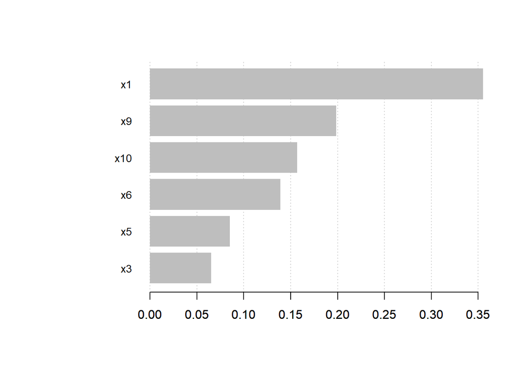

```r
xgb.importance(model = old_data_xgb) %>%
  xgb.plot.importance(top_n = 11)
```

##### new data

###### regression

```r
new_data_lm <- lm(md,data = sim_2)



new_data_lm %>% summary()
```

```
##
## Call:
## lm(formula = md, data = sim_2)
##
## Residuals:
##     Min      1Q  Median      3Q     Max
## -39.584  -7.410   1.337   8.199  31.888
##
## Coefficients:
##             Estimate Std. Error t value Pr(>|t|)
## (Intercept)  -0.9047     1.4256  -0.635    0.527
## x1            0.5629     1.4401   0.391    0.697
## x3           -0.1657     1.4485  -0.114    0.909
## x5           -1.7389     1.4464  -1.202    0.232
## x6           -0.3212     1.6024  -0.200    0.842
## x9            1.8680     1.4031   1.331    0.186
## x10           1.4307     1.2948   1.105    0.272
##
## Residual standard error: 13.83 on 93 degrees of freedom
## Multiple R-squared:  0.04169,    Adjusted R-squared:  -0.02014
## F-statistic: 0.6742 on 6 and 93 DF,  p-value: 0.6707
```

```r
print("train MSE")
```

```
## [1] "train MSE"
```

```r
label  <- new_data_lm %>% predict(sim_2)
mean((sim_2$y-label)^2)
```

```
## [1] 177.7599
```

```r
print("test MSE")
```

```
## [1] "test MSE"
```

```r
label  <- new_data_lm %>% predict(sim_3)
mean((sim_3$y-label)^2)
```

```
## [1] 307.3119
```

###### XGboost

```r
new_data_xgb <- xgboost(data = data.matrix(sim_2[,VS]),
label = sim_2[,"y"],
# eta = 0.5,
# max_depth = 10,
nround=25,
# subsample = 0.7,
# colsample_bytree = 0.7,
objective = "reg:squarederror",
verbose = 0
)
print("train MSE")
```

```
## [1] "train MSE"
```

```r
label  <- predict(new_data_xgb,xgb.DMatrix(data.matrix(sim_2[,VS])))
mean((sim_2$y-label)^2)
```

```
## [1] 0.4391373
```

```r
print("test MSE")
```

```
## [1] "test MSE"
```

```r
label  <- predict(new_data_xgb,xgb.DMatrix(data.matrix(sim_3[,VS])))
mean((sim_3$y-label)^2)
```

```
## [1] 351.2169
```

```r
xgb.importance(model = new_data_xgb)
```

| Feature | Gain | Cover | Frequency |
| --- | --- | --- | --- |
| x10 | 0.27908496 | 0.1671119 | 0.1176471 |
| x1 | 0.23807744 | 0.1941085 | 0.2752101 |
| x3 | 0.16397138 | 0.1772357 | 0.1911765 |
| x6 | 0.12533479 | 0.1434899 | 0.1344538 |
| x9 | 0.09789028 | 0.1586052 | 0.1365546 |
| x5 | 0.09564115 | 0.1594488 | 0.1449580 |

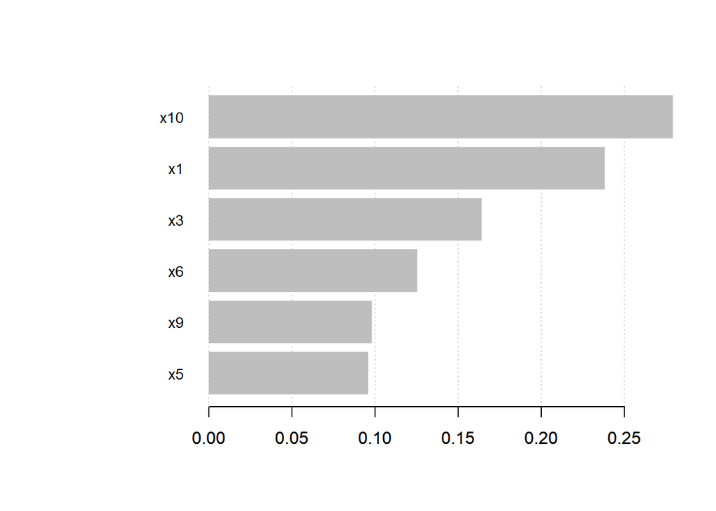

```r
xgb.importance(model = new_data_xgb) %>%
  xgb.plot.importance(top_n = 11)
```

#### use Gain to Variable Selection

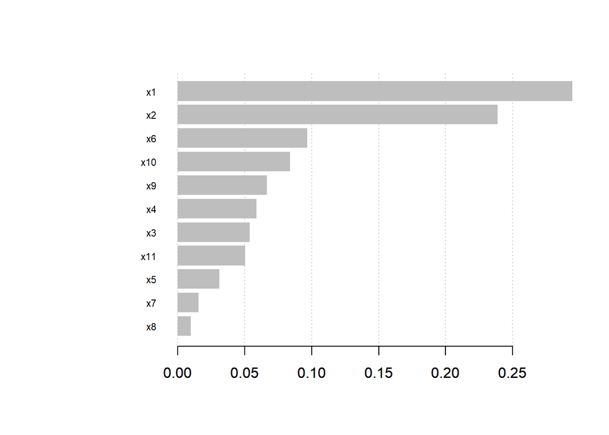

```r
xgb_test <- xgboost(data = data.matrix(sim[,-1]),
label = sim[,"y"],
# eta = 0.5,
# max_depth = 10,
nround=25,
# subsample = 0.7,
# colsample_bytree = 0.7,
objective = "reg:squarederror",
verbose = 0
)

xgb.importance(model = xgb_test) %>%
  xgb.plot.importance(top_n = 11)
```

```r
md <- formula(y~x1+x2+x4+x6+x9+x10)
VS <- c(1,2,4,6,9,10)+1
```

##### old data

###### regression

```r
old_data_lm <- lm(md,data = sim)



old_data_lm %>% summary()
```

```
##
## Call:
## lm(formula = md, data = sim)
##
## Residuals:
##     Min      1Q  Median      3Q     Max
## -57.669  -5.882   0.902   8.388  27.445
##
## Coefficients:
##             Estimate Std. Error t value Pr(>|t|)
## (Intercept)  -0.6702     1.4704  -0.456   0.6496
## x1            2.3768     1.5364   1.547   0.1253
## x2            1.0655     1.4260   0.747   0.4568
## x4           -0.3132     1.2598  -0.249   0.8042
## x6            2.6405     1.3732   1.923   0.0576 .
## x9            2.8672     1.4195   2.020   0.0463 *
## x10          -1.4942     1.2326  -1.212   0.2285
## ---
## Signif. codes:  0 '***' 0.001 '**' 0.01 '*' 0.05 '.' 0.1 ' ' 1
##
## Residual standard error: 13.73 on 93 degrees of freedom
## Multiple R-squared:  0.1157, Adjusted R-squared:  0.05861
## F-statistic: 2.027 on 6 and 93 DF,  p-value: 0.06968
```

```r
print("train MSE")
```

```
## [1] "train MSE"
```

```r
label  <- old_data_lm %>% predict(sim)
mean((sim$y-label)^2)
```

```
## [1] 175.2713
```

```r
print("test MSE")
```

```
## [1] "test MSE"
```

```r
label  <- old_data_lm %>% predict(sim_3)
mean((sim_3$y-label)^2)
```

```
## [1] 339.9789
```

###### XGboost

```r
old_data_xgb <- xgboost(data = data.matrix(sim[,VS]),
label = sim[,"y"],
# eta = 0.5,
# max_depth = 10,
nround=25,
# subsample = 0.7,
# colsample_bytree = 0.7,
objective = "reg:squarederror",
verbose = 0
)
print("train MSE")
```

```
## [1] "train MSE"
```

```r
label  <- predict(old_data_xgb,xgb.DMatrix(data.matrix(sim[,VS])))
mean((sim$y-label)^2)
```

```
## [1] 0.3297141
```

```r
print("test MSE")
```

```
## [1] "test MSE"
```

```r
label  <- predict(old_data_xgb,xgb.DMatrix(data.matrix(sim_3[,VS])))
mean((sim_3$y-label)^2)
```

```
## [1] 374.6138
```

```r
xgb.importance(model = old_data_xgb)
```

| Feature | Gain | Cover | Frequency |
| --- | --- | --- | --- |
| x1 | 0.34765165 | 0.29367263 | 0.28868360 |
| x2 | 0.25249681 | 0.21045392 | 0.18475751 |
| x6 | 0.14575371 | 0.14779917 | 0.15473441 |
| x10 | 0.10217704 | 0.10392022 | 0.08775982 |
| x9 | 0.08595014 | 0.15859697 | 0.15242494 |
| x4 | 0.06597065 | 0.08555708 | 0.13163972 |

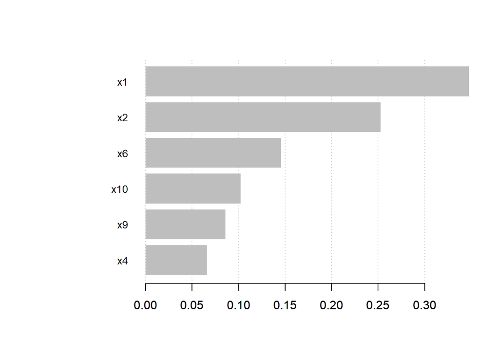

```r
xgb.importance(model = old_data_xgb) %>%
  xgb.plot.importance(top_n = 11)
```

##### new data

###### regression

```r
new_data_lm <- lm(md,data = sim_2)



new_data_lm %>% summary()
```

```
##
## Call:
## lm(formula = md, data = sim_2)
##
## Residuals:
##     Min      1Q  Median      3Q     Max
## -39.425  -6.915  -0.261   8.693  35.538
##
## Coefficients:
##             Estimate Std. Error t value Pr(>|t|)
## (Intercept) -0.90518    1.43214  -0.632    0.529
## x1           0.30696    1.43020   0.215    0.831
## x2          -0.04876    1.32348  -0.037    0.971
## x4          -2.13842    1.45519  -1.470    0.145
## x6          -0.33681    1.59960  -0.211    0.834
## x9           1.87799    1.39656   1.345    0.182
## x10          1.43145    1.29899   1.102    0.273
##
## Residual standard error: 13.78 on 93 degrees of freedom
## Multiple R-squared:  0.04841,    Adjusted R-squared:  -0.01299
## F-statistic: 0.7884 on 6 and 93 DF,  p-value: 0.5812
```

```r
print("train MSE")
```

```
## [1] "train MSE"
```

```r
label  <- new_data_lm %>% predict(sim_2)
mean((sim_2$y-label)^2)
```

```
## [1] 176.5135
```

```r
print("test MSE")
```

```
## [1] "test MSE"
```

```r
label  <- new_data_lm %>% predict(sim_3)
mean((sim_3$y-label)^2)
```

```
## [1] 315.5074
```

###### XGboost

```r
new_data_xgb <- xgboost(data = data.matrix(sim_2[,VS]),
label = sim_2[,"y"],
# eta = 0.5,
# max_depth = 10,
nround=25,
# subsample = 0.7,
# colsample_bytree = 0.7,
objective = "reg:squarederror",
verbose = 0
)
print("train MSE")
```

```
## [1] "train MSE"
```

```r
label  <- predict(new_data_xgb,xgb.DMatrix(data.matrix(sim_2[,VS])))
mean((sim_2$y-label)^2)
```

```
## [1] 0.2930155
```

```r
print("test MSE")
```

```
## [1] "test MSE"
```

```r
label  <- predict(new_data_xgb,xgb.DMatrix(data.matrix(sim_3[,VS])))
mean((sim_3$y-label)^2)
```

```
## [1] 246.4411
```

```r
xgb.importance(model = new_data_xgb)
```

| Feature | Gain | Cover | Frequency |
| --- | --- | --- | --- |
| x2 | 0.25406519 | 0.28724077 | 0.23030303 |
| x10 | 0.22368266 | 0.14432337 | 0.11313131 |
| x1 | 0.18380779 | 0.16316344 | 0.30303030 |
| x9 | 0.16771775 | 0.17110721 | 0.13737374 |
| x4 | 0.10712606 | 0.14586995 | 0.12525253 |
| x6 | 0.06360055 | 0.08829525 | 0.09090909 |

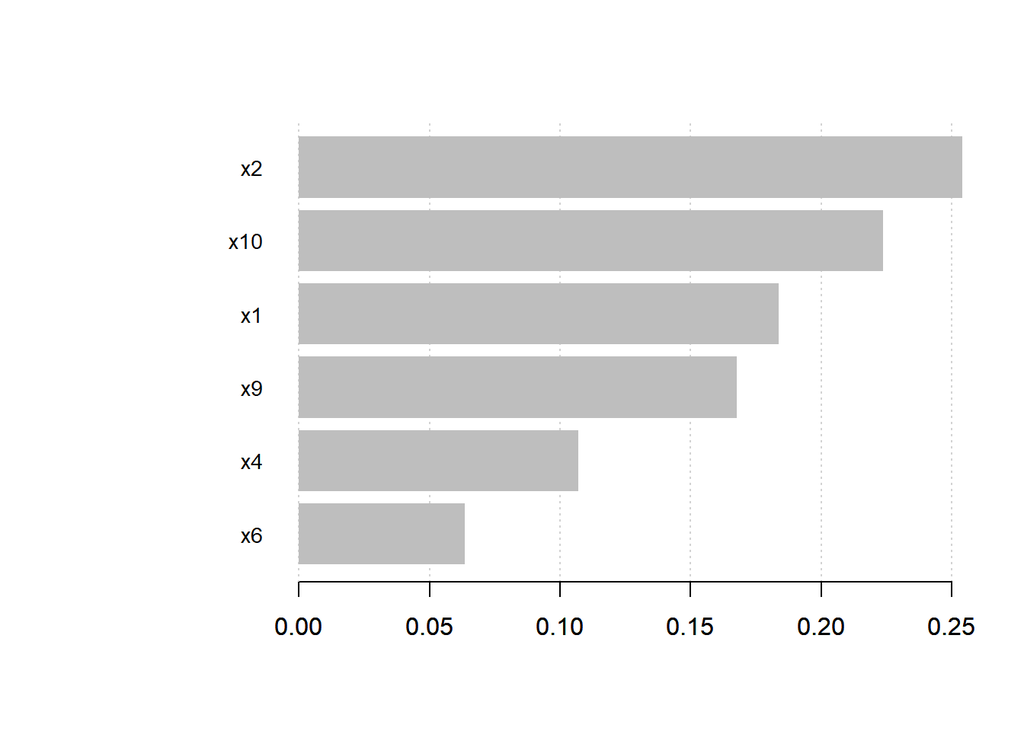

```r
xgb.importance(model = new_data_xgb) %>%
  xgb.plot.importance(top_n = 11)
```

### 第二次

```r
set.seed(17423)
x <- rmvnorm(n = 100,mean = c(0,0,0,0,0,0,0,0,0,0),sigma = diag(1,10))
set.seed(5997)
x_11 <- rnorm(n = 100)
set.seed(515)
sd <- rnorm(100,sd = 4)
y <- 10*x[,1]*x[,2]-7*x[,3]*x[,4]-8*x[,6]*x[,9]+sd
sim <- data.frame(y,x,x_11)


set.seed(12632)
x <- rmvnorm(n = 100,mean = c(0,0,0,0,0,0,0,0,0,0),sigma = diag(1,10))
set.seed(5998)
x_11 <- rnorm(n = 100)
set.seed(597)
sd <- rnorm(100,sd = 4)
y <- 10*x[,1]*x[,2]-7*x[,3]*x[,4]-8*x[,6]*x[,9]+sd
sim_2 <- data.frame(y,x,x_11)

set.seed(12772)
x <- rmvnorm(n = 100,mean = c(0,0,0,0,0,0,0,0,0,0),sigma = diag(1,10))
set.seed(565579)
x_11 <- rnorm(n = 100)
set.seed(51452)
sd <- rnorm(100,sd = 4)
y <- 10*x[,1]*x[,2]-7*x[,3]*x[,4]-8*x[,6]*x[,9]+sd
sim_3 <- data.frame(y,x,x_11)




names(sim) <- c("y",paste0("x",1:11))
names(sim_2) <- c("y",paste0("x",1:11))
names(sim_3) <- c("y",paste0("x",1:11))
```